# Supplementary Code for manuscript entitled - Rabies virus interferon antagonist P protein selectively modulates interferon signalling to inhibit antiviral genes while supporting proviral gene expression

Alebachew Messele Kebede Cassandra T. David Stephen M. Rawlinson Celine Deffrasnes Paul Gooley Samuel C. Forster Gregory W. Moseley

2026-07-10

# Introduction

This reproducible and dynamic report was created using Rmarkdown and the Knitr package, and summarizes the basic code and outputs (plots, tables, etc) produced during the analysis. The relative file paths indicated in the code below assume that your project working directly is structured as indicated in the **README.MD** file.

# Background

Rabies virus P-protein (RABV-P) binds and inhibits IFN-activated STAT1/2 and so are typically considered to mediate shutdown of the IFN response. However, IFN signalling is not exclusively antiviral, with many IRGs reported to be required for or to facilitate infection by certain viruses. How viruses coordinate the apparent need to suppress certain antiviral IRGs, while presumably permitting the expression of others, including ‘proviral’ IRGs is poorly defined. However, it has been shown that type-I IFN can activate multiple pathways other than classical STAT1/2, so discriminatory targeting of specific pathways by IFN-antagonists may enable highly selective regulation of distinct IRGs, dependent on the requirements of the specific virus. Here, we analyse the global effects of RABV-P protein on the IFN-regulated transcriptome.

The code below shows how raw data was preprocessed, mapped, and analyzed to investigate the effect of RABV-P protein on the expression of ISGs.

# Reproducibility and accessibility

The library structure is as follows : R1 primer is used to read sample index (8 bp) followed by 10 bp unique molecular identifier (UMI). R2 primer reads the 3’ end of the cDNA in sense orientation.

Sample indexes are provided as fasta file.

Demultiplexing with cutadapt

```bash
cutadapt \
    -g file:Sample_Index_barcode.fasta \
    --action=none \
    -e 0 \
    --pair-filter=both \
    -o demux/{name}_R1.fastq.gz \
    -p demux/{name}_R2.fastq.gz \
    *.fastq.gz \
    *.fastq.gz
```

# R packages used for this analysis

A variety of R packages was used for this analysis. All graphics and data wrangling were handled using the tidyverse suite of packages. All packages used are available from the Comprehensive R Archive Network (CRAN), Bioconductor.org, or Github. To avoid conflict additional R packages are added or detached in the latter part of the analysis.

```r
# source("02_Packages.R")
library(here)
library(org.Hs.eg.db)
library(AnnotationDbi)
library(biomaRt)
library(magrittr)
library(RColorBrewer)
library(openxlsx)
library(dplyr)
library(stringr)
library(readr)
library(edgeR)
library(gt)
library(ggridges)
library(circlize)
```

# Preprocessing

Raw RNAseq reads were pre-processed using ScPipe package (https://github.com/LuyiTian/scPipe) which was used for demultiplexing, transcript mapping and quality control of raw sequencing data. Reads were aligned to the human primary assembly genome file using the Rsubread (v3.17) package.

```r
library(scPipe)
# Barcode annotation
barcode_annotation <- here::here("data_raw", "210119_NB551334_0179_AH7WGJBGXH", "barcode_annotation.csv")
# barcode_annotation <- here::here("data_raw", "210118_NB551334_0178_AH7YFLBGXH", "barcode_annotation.csv")

# Parameters
bc.len <- 8
UMI.len <- 10
UMI.cor <- 1
threads <- 16

# Genome, annotation file, and Index file
genome <- here::here("data_raw", "NCBI_Reference", "GCF_000001405.40_GRCh38.p14_genomic.fna")
genome.index <- here::here("data_raw", "Index", "GRCH_38")
gff3 <- here::here("data_raw", "NCBI_Reference", "GCF_000001405.40_GRCh38.p14_genomic.gff")
gtf <- here::here("data_raw", "NCBI_Reference", "GCF_000001405.40_GRCh38.p14_genomic.gtf")

# Output folder and files, change output director etc when analyzing different read file
out_dir <- "Aim1_210119_NCBI"
combined_fastq <- file.path(out_dir, "trimmed.fastq.gz")
aligned_bam <- file.path(out_dir, "aligned.bam")
mapped_bam <- file.path(out_dir, "aligned.mapped.bam")

# Raw reads: R1 corresponds to Trevseq R2 which has the transcript, R1 has barcode and UMI
fq.transcript <- here::here("data_raw", "210119_NB551334_0179_AH7WGJBGXH", "fastq", "MultiplexRNASeq_S1_R2_001.fastq.gz")
fq.barcode <- here::here("data_raw", "210119_NB551334_0179_AH7WGJBGXH", "fastq", "MultiplexRNASeq_S1_R1_001.fastq.gz")

# Raw data for R1 and R2 are not currently in the Raw data folder but are written here to keep the narrative structure. Data can be retrieved from ENA for analysis

# Analysis
# Read structure; UMI Barcode bs2 = 0 bl2 = 8 us = 8 ul = 10
#sc_trim_barcode(
#  outfq = combined_fastq,
#  r1 = fq.transcript,
#  r2 = fq.barcode,
#  read_structure = list(
#    bs1 = -1, bl1 = 0,
#    bs2 = 0, bl2 = 8,
#   us = 8, ul = 10
#  )
#  )

# Align reads
#Rsubread::align(
 # index = genome.index,
 # readfile1 = combined_fastq,
 # output_file = aligned_bam,
 # nthreads = threads
#)

# Assigning reads to annotated exons
#sc_exon_mapping(
#  inbam = aligned_bam,
#  outbam = mapped_bam,
#  annofn = gff3,
#  bc_len = bc.len,
#  UMI_len = UMI.len,
#  nthreads = threads
#)

# Demultiplex
sc_demultiplex(
  inbam = mapped_bam,
  outdir = out_dir,
  bc_anno = barcode_annotation,
  has_UMI = TRUE,
  nthreads = threads
)

# Gene counting
sc_gene_counting(
  outdir = out_dir,
  bc_anno = barcode_annotation,
  UMI_cor = 1
)
```

# Import and analyze RNAseq data

## Sample Info

```r
#read in experimental variables
targets <- read_tsv(here::here("data_processed", "targets.txt"))
# use gt package to produce table of study desig
gt(targets)
```

| Sample | Protein | Time | Conditions |
| --- | --- | --- | --- |
| 1a_IFN0hFLAG_1 | FLAG | 0hr | FLAG_tag |
| 1b_IFN0hFLAG_2 | FLAG | 0hr | FLAG_tag |
| 1c_IFN0hFLAG_3 | FLAG | 0hr | FLAG_tag |
| 2a_IFN0hP1_1 | P1 | 0hr | P1_expressed |
| 2b_IFN0hP1_2 | P1 | 0hr | P1_expressed |
| 2c_IFN0hP1_3 | P1 | 0hr | P1_expressed |
| 3a_IFN0hP3_1 | P3 | 0hr | P3_expressed |
| 3b_IFN0hP3_2 | P3 | 0hr | P3_expressed |
| 3c_IFN0hP3_3 | P3 | 0hr | P3_expressed |
| 4a_IFN1hFLAG_1 | FLAG | 1hr | IFN_treatment_1h |
| 4b_IFN1hFLAG_2 | FLAG | 1hr | IFN_treatment_1h |
| 4c_IFN1hFLAG_3 | FLAG | 1hr | IFN_treatment_1h |
| 5a_IFN_1OFFhP1_1 | P1 | 1hr | IFN_treatment_1h_P1_expressed |
| 5b_IFN_1OFFhP1_2 | P1 | 1hr | IFN_treatment_1h_P1_expressed |
| 5c_IFN_1OFFhP1_3 | P1 | 1hr | IFN_treatment_1h_P1_expressed |
| 6a_IFN_1OFFhP3_1 | P3 | 1hr | IFN_treatment_1h_P3_expressed |
| 6b_IFN_1OFFhP3_2 | P3 | 1hr | IFN_treatment_1h_P3_expressed |
| 6c_IFN_1OFFhP3_3 | P3 | 1hr | IFN_treatment_1h_P3_expressed |
| 7a_IFN_6OFFhFLAG_1 | FLAG | 6hr | IFN_treatment_6h |
| 7b_IFN_6OFFhFLAG_2 | FLAG | 6hr | IFN_treatment_6h |
| 7c_IFN_6OFFhFLAG_3 | FLAG | 6hr | IFN_treatment_6h |
| 8a_IFN_6OFFhP1_1 | P1 | 6hr | IFN_treatment_6h_P1_expressed |
| 8b_IFN_6OFFhP1_2 | P1 | 6hr | IFN_treatment_6h_P1_expressed |
| 8c_IFN_6OFFhP1_3 | P1 | 6hr | IFN_treatment_6h_P1_expressed |
| 9a_IFN_6OFFhP3_1 | P3 | 6hr | IFN_treatment_6h_P3_expressed |
| 9b_IFN_6OFFhP3_2 | P3 | 6hr | IFN_treatment_6h_P3_expressed |
| 9c_IFN_6OFFhP3_3 | P3 | 6hr | IFN_treatment_6h_P3_expressed |
| 10a_IFN_24ONFLAG_1 | FLAG | 24hr | IFN_treatment_24h |
| 10b_IFN_24ONFLAG_2 | FLAG | 24hr | IFN_treatment_24h |
| 10c_IFN_24ONFLAG_3 | FLAG | 24hr | IFN_treatment_24h |
| 11a_IFN_24ONP1_1 | P1 | 24hr | IFN_treatment_24h_P1_expressed |
| 11b_IFN_24ONP1_2 | P1 | 24hr | IFN_treatment_24h_P1_expressed |
| 11c_IFN_24ONP1_3 | P1 | 24hr | IFN_treatment_24h_P1_expressed |
| 12a_IFN_24ONP3_1 | P3 | 24hr | IFN_treatment_24h_P3_expressed |
| 12b_IFN_24ONP3_2 | P3 | 24hr | IFN_treatment_24h_P3_expressed |
| 12c_IFN_24ONP3_3 | P3 | 24hr | IFN_treatment_24h_P3_expressed |
| 13a_IFN_24OFFFLAG_1 | FLAG | 24hr_OFF | IFN_treatment_24h_OFF |
| 13b_IFN_24OFFFLAG_2 | FLAG | 24hr_OFF | IFN_treatment_24h_OFF |
| 13c_IFN_24OFFFLAG_3 | FLAG | 24hr_OFF | IFN_treatment_24h_OFF |
| 14a_IFN_24OFFP1_1 | P1 | 24hr_OFF | IFN_treatment_24h_OFF_P1_expressed |
| 14b_IFN_24OFFP1_2 | P1 | 24hr_OFF | IFN_treatment_24h_OFF_P1_expressed |
| 14c_IFN_24OFFP1_3 | P1 | 24hr_OFF | IFN_treatment_24h_OFF_P1_expressed |
| 15a_IFN_24OFFP3_1 | P3 | 24hr_OFF | IFN_treatment_24h_OFF_P3_expressed |
| 15b_IFN_24OFFP3_2 | P3 | 24hr_OFF | IFN_treatment_24h_OFF_P3_expressed |
| 15c_IFN_24OFFP3_3 | P3 | 24hr_OFF | IFN_treatment_24h_OFF_P3_expressed |

Data for the P1 isoform of RABV-P were included for the remainder of the analysis

```r
seqdata<- subset(seqdata,select=c('gene_id',
                                  '1a_IFN0hFLAG_1','1b_IFN0hFLAG_2','1c_IFN0hFLAG_3',
                                  '2a_IFN0hP1_1','2b_IFN0hP1_2','2c_IFN0hP1_3',
                                  '4a_IFN1hFLAG_1','4b_IFN1hFLAG_2','4c_IFN1hFLAG_3',
                                  '5a_IFN_1OFFhP1_1','5b_IFN_1OFFhP1_2','5c_IFN_1OFFhP1_3',
                                  '7a_IFN_6OFFhFLAG_1','7b_IFN_6OFFhFLAG_2','7c_IFN_6OFFhFLAG_3',
                                  '8a_IFN_6OFFhP1_1','8b_IFN_6OFFhP1_2','8c_IFN_6OFFhP1_3',
                                  '10a_IFN_24ONFLAG_1','10b_IFN_24ONFLAG_2','10c_IFN_24ONFLAG_3',
                                  '11a_IFN_24ONP1_1','11b_IFN_24ONP1_2','11c_IFN_24ONP1_3'))


targets <- targets %>% dplyr::filter(Sample %in% c("1a_IFN0hFLAG_1","1b_IFN0hFLAG_2","1c_IFN0hFLAG_3",
                                                     "2a_IFN0hP1_1","2b_IFN0hP1_2", "2c_IFN0hP1_3",
                                                     "4a_IFN1hFLAG_1","4b_IFN1hFLAG_2","4c_IFN1hFLAG_3",
                                                     "5a_IFN_1OFFhP1_1","5b_IFN_1OFFhP1_2","5c_IFN_1OFFhP1_3",
                                                     "7a_IFN_6OFFhFLAG_1","7b_IFN_6OFFhFLAG_2","7c_IFN_6OFFhFLAG_3",
                                                     "8a_IFN_6OFFhP1_1","8b_IFN_6OFFhP1_2","8c_IFN_6OFFhP1_3",
                                                     "10a_IFN_24ONFLAG_1","10b_IFN_24ONFLAG_2","10c_IFN_24ONFLAG_3",
                                                     "11a_IFN_24ONP1_1","11b_IFN_24ONP1_2","11c_IFN_24ONP1_3"))
# gt(targets)
```

```r
paste.factor <- function(..., sep = " "){
  y <- list(...)
  y <- lapply(y, function(x){
    if(!is.factor(x)) x <- factor(x)
    x
  })
  levels <- lapply(y, function(x) unique(c(levels(x), NA)))
  levels <- apply(expand.grid(rev(levels))[, length(y):1, drop = FALSE], 1, paste, collapse = sep)
  y.factor <- factor(do.call(what = "paste", args = c(y, sep = sep)), levels = levels)
  droplevels(y.factor)
}
```

Color to discern the various groups and conditions of the experiment

```r
group <- paste.factor(targets$Protein, factor(targets$Time, levels = c("0hr", "1hr", "6hr", "24hr","24hr_OFF")), sep = "_")


group.cols <- c(brewer.pal(8, "Blues")[3],brewer.pal(4, "BuGn")[3],brewer.pal(4, "YlOrRd")[3],
                brewer.pal(8, "BrBG")[3],brewer.pal(3, "Greens")[3],brewer.pal(6, "Greys")[3],
                brewer.pal(3, "Oranges")[3],brewer.pal(8, "OrRd")[3],brewer.pal(4, "PuBu")[3],
                brewer.pal(3, "PuBuGn")[3],brewer.pal(6, "PuRd")[3],brewer.pal(8, "Purples")[3],
                brewer.pal(6, "RdPu")[3],brewer.pal(8, "Reds")[3],brewer.pal(8, "YlGn")[3]) %>% magrittr::set_names(levels(group))

Protein.cols <- brewer.pal(8, "Accent") %>% `[`(1:length(unique(targets$Protein))) %>% magrittr::set_names(unique(targets$Protein))

Time.cols <- brewer.pal(8, "Set1") %>% `[`(1:length(unique(targets$Time))) %>% magrittr::set_names(unique(targets$Time))

IFN.Cols <- c( "0hr"= "#feebe2","1hr"= "#fbb4b9","6hr" = "#f768a1","24hr"= "#c51b8a")
```

```r
#Change first column to rowname
countdata <- seqdata[,-1]
rownames(countdata) <- seqdata[,1]
```

## Annotation

Gene Annotation data retrieved from org.Hs.eg.db (v 3.23) package.

Next we make DGEList and export it for later use. DGEList is a specialized data structure that holds our raw count data and experimental design information.

```r
myDGElist <- DGEList(counts = countdata, genes = genes[rownames(countdata), ], samples = targets)
log2.cpm <- edgeR::cpm(myDGElist, log = TRUE, prior.count = 2)
```

```r
write.csv(cbind(genes[rownames(countdata), ], countdata), file = here::here("results", "tables", "EntrezlID_counts.csv"), quote = FALSE, row.names = FALSE)

write.csv(cbind(Sample = colnames(countdata), targets), file = here::here("results", "tables", "P1_samples.csv"), quote = FALSE, row.names = FALSE)
```

## QC

Library size

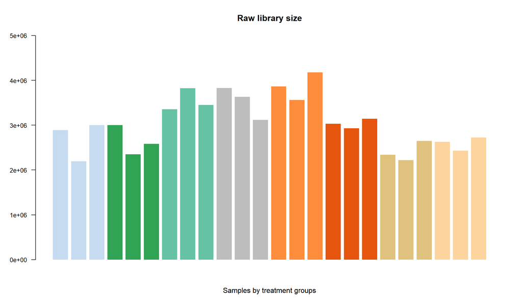

```r
# png(here::here("results", "figures", "library_size.png"), width = 1200, height = 800, res = 150)
# pdf(here::here("results", "figures", "library_size.pdf"), width = 10, height = 7)

par(mar = c(5, 4, 4, 2) + 0.1)

unit <- 1e6
lim.max <- ceiling(max(colSums(countdata)) / unit) * unit

all.count.plot <- barplot(colSums(countdata),
                          col = group.cols[as.character(group)], las = 2, cex.axis = 0.85,
                          cex.names = 0.75, main = "Raw library size", xlab = "Samples by treatment groups",  ylim = c(0, lim.max),
                          space = NULL,
                          xaxt = "n", border = NA)
```

```r
# dev.off()
```

MDS plot

```r
mds.raw <- plotMDS(log2.cpm, ndim = 8, plot = FALSE)
```

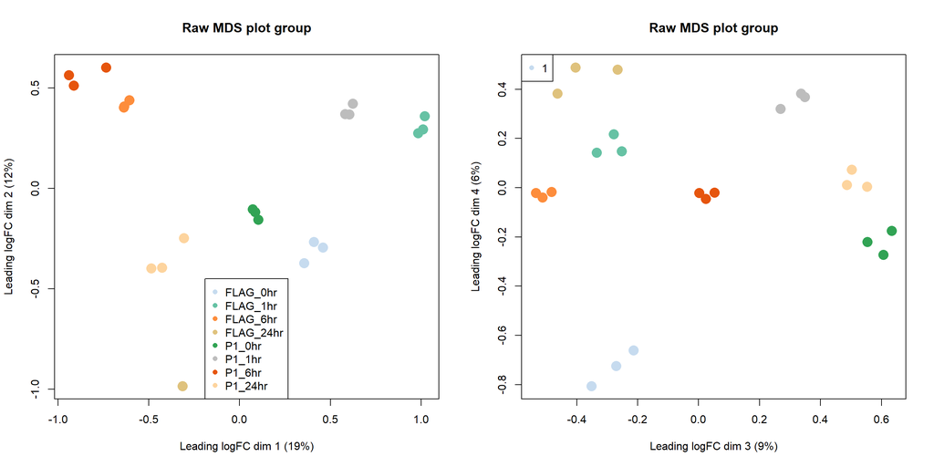

```r
# pdf(file.path(figures_dir, "MDS_plot.pdf"), width = 10, height = 7)

par(mfrow = c(1, 2))
plotMDS(mds.raw, dim.plot = c(1,2), col = group.cols[as.character(group)],
       # labels = samples$group,
       pch = 16,
        cex = 2,
        # xlim = lim, ylim = lim,
        main = "Raw MDS plot group"
        )
legend("bottom", legend = levels(group), pch = 16, col = group.cols, ncol = 1, pt.cex = 1)

plotMDS(mds.raw, dim.plot = c(3,4), col =  group.cols[as.character(group)],
       # labels = samples$group,
       pch = 16,
        cex = 2,
        # xlim = lim, ylim = lim,
        main = "Raw MDS plot group"
        )
legend("topleft", legend = levels(myDGElist$samples$group), pch = 16, col = group.cols, ncol = 1, pt.cex = 1)
```

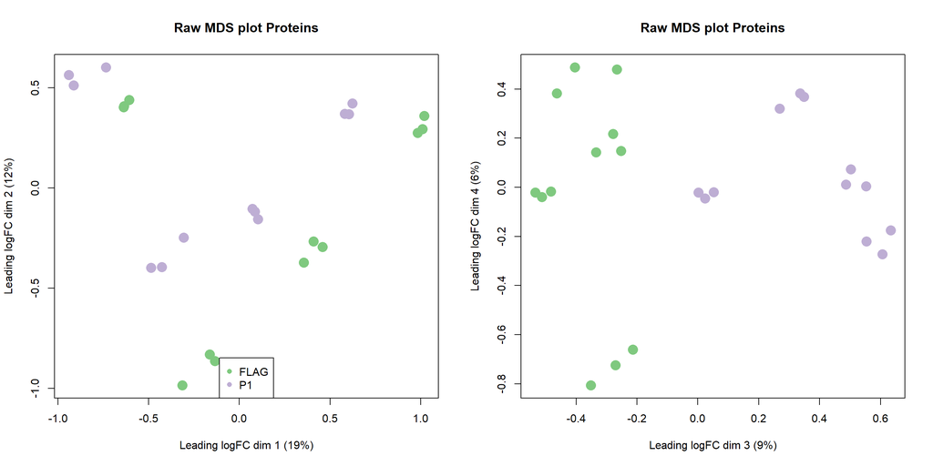

```r
# legend("topleft", legend = levels(y$samples$group), pch = 16, col = group.cols, ncol = 1, pt.cex = 1)
plotMDS(mds.raw, dim.plot = c(1,2), col = Protein.cols[myDGElist$samples$Protein],
       # labels = samples$group,
       pch = 16,
        cex = 2,
        # xlim = lim, ylim = lim,
        main = "Raw MDS plot Proteins"
        )
legend("bottom", legend = names(Protein.cols), pch = 16, col = Protein.cols, ncol = 1, pt.cex = 1)

plotMDS(mds.raw, dim.plot = c(3,4), col = Protein.cols[myDGElist$samples$Protein],
       # labels = samples$group,
       pch = 16,
        cex = 2,
        # xlim = lim, ylim = lim,
        main = "Raw MDS plot Proteins"
        )
```

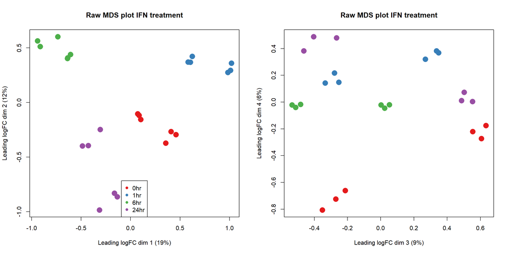

```r
plotMDS(mds.raw, dim.plot = c(1,2), col = Time.cols[myDGElist$samples$Time],
       # labels = samples$group,
       pch = 16,
        cex = 2,
        # xlim = lim, ylim = lim,
        main = "Raw MDS plot IFN treatment"
        )
legend("bottom", legend = names(Time.cols), pch = 16, col = Time.cols, ncol = 1, pt.cex = 1)

plotMDS(mds.raw, dim.plot = c(3,4), col = Time.cols[myDGElist$samples$Time],
       # labels = samples$group,
       pch = 16,
        cex = 2,
        # xlim = lim, ylim = lim,
        main = "Raw MDS plot IFN treatment"
        )
```

```r
# dev.off()
```

## Filter data

```r
#Filtering by expression
keep <- filterByExpr(myDGElist, group=group)
myDGElist.filtered <- myDGElist[keep , , keep.lib.sizes = FALSE]
log2.cpm.filtered <- edgeR::cpm(myDGElist.filtered, log = TRUE, prior.count = 2)
```

Density plot

```r
# source("05_density_plot.R")
density.plot <- function(expression, col, lwd = 2, ...){
  densities <- apply(expression, 2, density)
  high.peak <- which.max(sapply(densities, function(d) max(d$y)))

  plot(densities[[high.peak]],
       type = "l",
       lwd = lwd,
       col = col[high.peak],
       ...
  )

  for(i in (1:ncol(expression))[-high.peak]){
    lines(densities[[i]], col = col[i], lwd = lwd)
  }
}
```

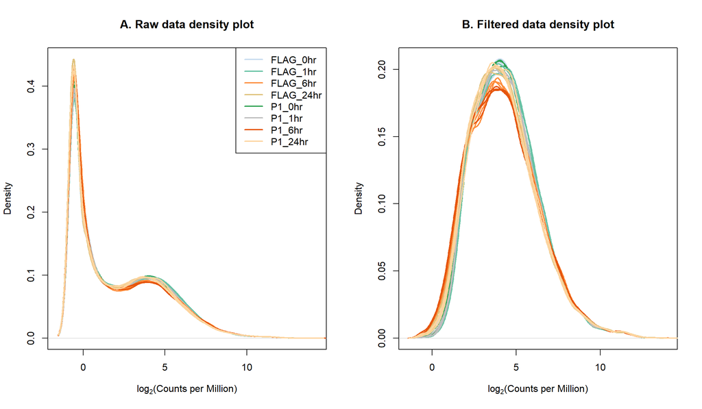

```r
#pdf(file.path(figures_dir, "Density_plot.pdf"), width = 10, height = 7)

par(mfrow=c(1,2))

density.plot(log2.cpm,  main = "A. Raw data density plot", col = group.cols[as.character(group)], xlab = expression("log"[2]*"(Counts per Million)"))
legend("topright", legend = levels(group), lwd = 2, col = group.cols[levels(group)])

density.plot(log2.cpm.filtered,  main = "B. Filtered data density plot", col = group.cols[as.character(group)], xlab = expression("log"[2]*"(Counts per Million)"))
```

```r
# dev.off()
```

## Normalization

```r
method <- "TMM"

myDGEList.norm <- calcNormFactors(myDGElist.filtered, method = method)
log2.cpm.filtered.norm <- edgeR::cpm(myDGEList.norm, log = TRUE, prior.count = 2)
log2.cpm.filtered.norm.relative <- log2.cpm.filtered.norm %>% subtract(apply(.[, group == levels(group)[1]], 1, mean))
```

Gene plot

```r
# source("06_gene_plot.R")

# gene_plot
gene.plot <- function(gene, groups = TRUE, full.expression = FALSE, raw.counts = FALSE,  ...){
  display.group <- group

  if(full.expression){
    display.group <- group
    if(raw.counts){
      data <- as.matrix(countdata)
    } else {
      data <- log2.cpm.filtered.norm
    }
  } else {
    data <- log2.cpm.filtered.norm

  }

  if(full.expression){
    gene.annotation <- genes
  } else {
    gene.annotation <- myDGElist$genes
  }

  ylab <- expression("log"[2]*"(Counts per Million)")
  if(raw.counts){
    ylab <- "Counts"
  }

  beeswarm::beeswarm(data[gene, groups] ~ droplevels(display.group[groups]),
                     pwcol = group.cols[as.character(display.group)][groups],
                     cex = 1.5,
                     ylab = ylab,
                     labels = sub("_", "\n", levels(droplevels(display.group[groups]))),
                     xlab = "",
                     las = 1, cex.axis = 1,
                     main = gene.annotation[gene, "SYMBOL"],
                     corral = "random", font.main = 4,
                     ...
  )
  # abline(v = which(diff(as.integer(factor(sub("_.*", "", levels(experiment.group))))) != 0) + 0.5)
}
```

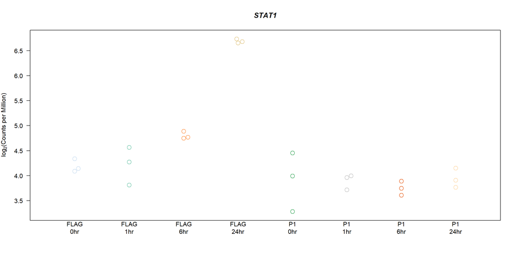

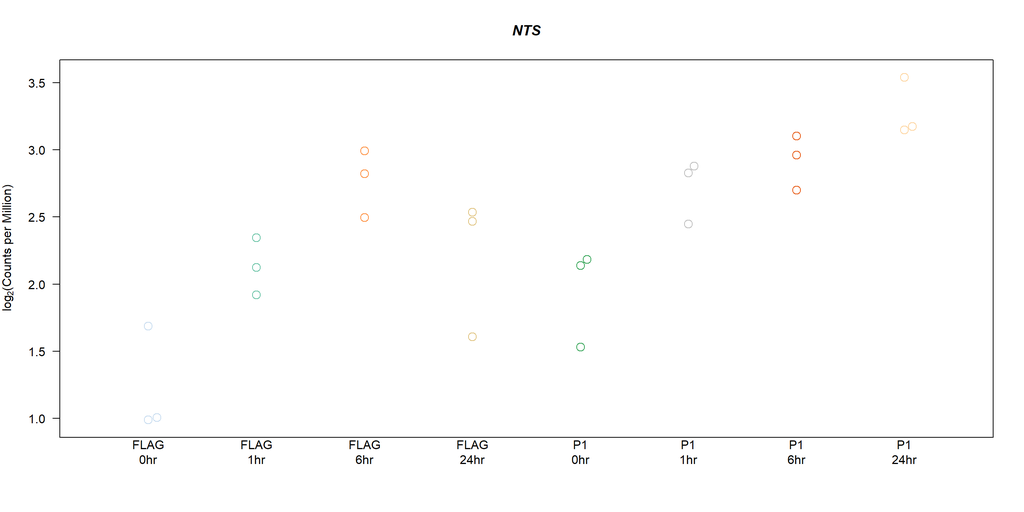

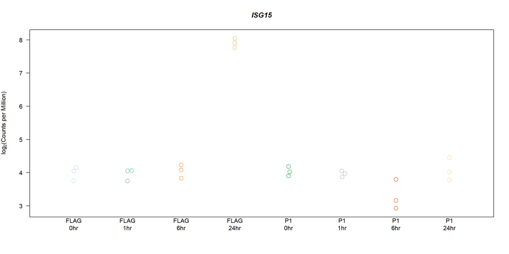

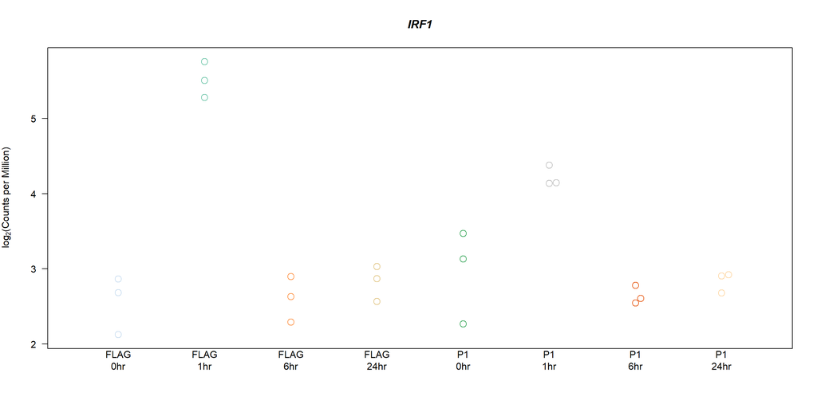

```r
# pdf(file.path(figures_dir, "Gene_plot.pdf"), width = 10, height = 7)

par(mfrow = c(1, 1))
of.interest <- c("STAT1","NTS", "ISG15", "IRF1")

for(goi in of.interest){
  id <- with(myDGElist$genes, ENTREZID[match(goi, SYMBOL)])
  if(!is.na(id)){
    gene.plot(id, rbe = NA, cex.axis = 1)
  }
}
```

```r
# dev.off()
```

## Design, VOOM transformation and Linear model fit

```r
design <- model.matrix(~0 + group)%>%
set_colnames(sub("group", "", colnames(.)))
```

VOOM transformation

```r
v <- voom(myDGEList.norm, design, plot = FALSE, save.plot = TRUE)
```

Linear model fit

```r
fit <- lmFit(v, design, plot =TRUE)
```

VOOM plot

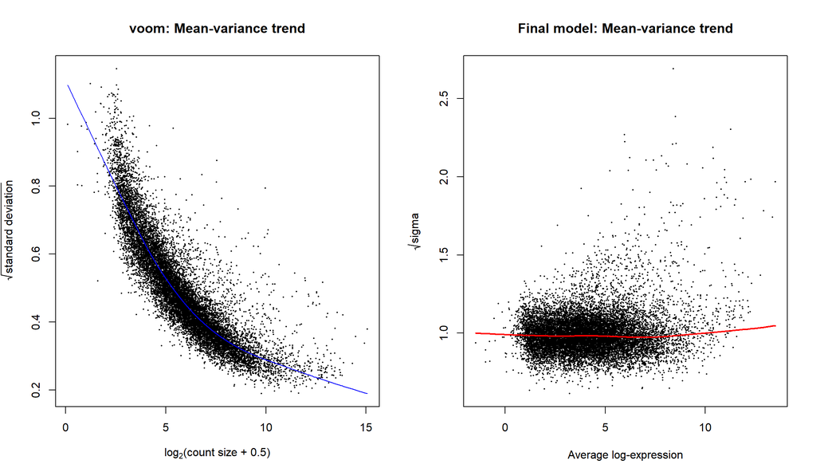

```r
# pdf(file.path(figures_dir, "Voom_plot.pdf"), width = 10, height = 7)

# Your original code:
par(mfrow = c(1, 2))
with(v$voom.xy, plot(x, y, xlab = expression("log"[2]*"(count size + 0.5)"), ylab = expression(sqrt("standard deviation")), pch = 16, cex = 0.25))
title("voom: Mean-variance trend")
lines(v$voom.line, col = "blue")

# Add a trendline to the SA plot
plotSA(fit, ylab = expression(sqrt("sigma")), main = "Final model: Mean-variance trend")

# Extract the data used in plotSA
sa_data <- data.frame(AvgLogExpr = fit$Amean, SqrtSigma = sqrt(fit$sigma))

# Sort the data by average log-expression
sa_data <- sa_data[order(sa_data$AvgLogExpr), ]

# Add a LOWESS trend line
lines(lowess(sa_data$AvgLogExpr, sa_data$SqrtSigma), col = "red", lwd = 2)
```

```r
# dev.off()
```

Box plot

```r
pdf(file.path(figures_dir, "Box_plot.pdf"), width = 20, height = 10)

par(mfrow=c(1,2), mar=c(12, 4, 4, 2))
boxplot(log2.cpm.filtered.norm, col = group.cols[as.character(group)],  xlab="", ylab="Log2 counts per million",las=2,main="normalized logCPM")
## Let's add a blue horizontal line that corresponds to the median logCPM

boxplot(v$E, col = group.cols[as.character(group)], xlab="", ylab="Log2 counts per million",las=2,main="Voom transformed logCPM")
## Let's add a blue horizontal line that corresponds to the median logCPM
abline(h=median(v$E),col="blue")

dev.off()
```

Contrast

```r
cont.matrix <- makeContrasts(

                    P1_0hr.v.FLAG_0hr = P1_0hr - FLAG_0hr,

                    FLAG_1hr.v.FLAG_0hr = FLAG_1hr - FLAG_0hr,
                    FLAG_6hr.v.FLAG_0hr = FLAG_6hr - FLAG_0hr,
                    FLAG_24hr.v.FLAG_0hr = FLAG_24hr - FLAG_0hr,


                    P1_1hr.v.FLAG_0hr =  P1_1hr - FLAG_0hr,
                    P1_6hr.v.FLAG_0hr = P1_6hr - FLAG_0hr,
                    P1_24hr.v.FLAG_0hr = P1_24hr - FLAG_0hr,


                     levels = design
                 )

contrast.type <- list(
                     v = "\\.v\\." ,
                     Basal_P1 = "P1_0hr.v.FLAG_0hr",
                     IFN_Regulation = "FLAG_(1|6|24)hr(\\_OFF)?\\.v\\.FLAG_0hr",
                     P1_IFN = "P1_(1|6|24)hr(\\_OFF)?\\.v\\.FLAG_0hr",
                     Comparison_1hr = "(FLAG_1hr\\.v\\.FLAG_0hr|P1_1hr\\.v\\.FLAG_0hr)",
                     Comparison_6hr = "(FLAG_6hr\\.v\\.FLAG_0hr|P1_6hr\\.v\\.FLAG_0hr)",
                     Comparison_24hr = "(FLAG_24hr\\.v\\.FLAG_0hr|P1_24hr\\.v\\.FLAG_0hr)"

                 ) %>%
                lapply(grepl,colnames(cont.matrix))
```

# Differential gene expression analysis

```r
treat.fc <- 1.2
```

```r
fit2 <- contrasts.fit(fit, cont.matrix) %>% treat(lfc = log2(treat.fc))
fit2.eBayes <- contrasts.fit(fit, cont.matrix) %>% eBayes()
```

```r
results <- decideTests(fit2, method = "separate", adjust.method = "BH", p.value = 0.05)
summary(results)
```

```
##        P1_0hr.v.FLAG_0hr FLAG_1hr.v.FLAG_0hr FLAG_6hr.v.FLAG_0hr
## Down                  57                  12                 943
## NotSig             13604               13510               11857
## Up                    48                 187                 909
##        FLAG_24hr.v.FLAG_0hr P1_1hr.v.FLAG_0hr P1_6hr.v.FLAG_0hr
## Down                    163                76              1149
## NotSig                13354             13363             11466
## Up                      192               270              1094
##        P1_24hr.v.FLAG_0hr
## Down                  432
## NotSig              12903
## Up                    374
```

```r
results.summary <-summary(results)
```

Create data frames, classify if genes were affected or unaffected and then export to excel file

```r
# Create dataframe

# Define the style for rounding
round.style <- createStyle(numFmt = "0.000")

# Define the columns to extract from topTreat
tt.cols <- c("logFC", "P.Value", "adj.P.Val") # add "t" if you want t values for DecoulpeR analysis

# Generate a list of topTreat results for each contrast
tt.list <- lapply(colnames(cont.matrix), function(coef) {
  topTreat(fit2, coef, genelist = NULL, number = Inf, sort.by = "none") %>% `[`(, tt.cols)
}) %>%
  set_names(colnames(cont.matrix))

# Define the types and their corresponding contrasts
types <- list(
              P1_Expression = contrast.type$Basal_P1,
              IFN_Regulation = contrast.type$IFN_Regulation,
              Modulation = contrast.type$P1_IFN,
              All_comparisons = contrast.type$v,
              One_hour = contrast.type$Comparison_1hr,
              Six_hours = contrast.type$Comparison_6hr,
              TwentyFour_hours = contrast.type$Comparison_24hr
)

# Create a named list to store dataframes for each type
dataframes_list <- list()

# Iterate over each type and generate the corresponding dataframe
for (type.name in names(types)) {
  ct <- types[[type.name]]
  tt.merge <- do.call(what = "cbind", tt.list[ct]) %>%
    `[`(, order(rep(1:length(tt.cols), length.out = ncol(.))))
  res <- results[, ct] %>%
    set_colnames(paste(colnames(.), "Results", sep = "."))
  tt.merge <- cbind(fit2$genes, AveExpr = fit2$Amean, tt.merge, res)

  # Store the dataframe in the list
  dataframes_list[[type.name]] <- tt.merge
}

# Iterate over the dataframes_list and create individual dataframe objects
for (name in names(dataframes_list)) {
  df <- dataframes_list[[name]]

  # Assign the dataframe to a variable with the same name as the type
  assign(name, df)
}


# classify_genes
# Function to classify genes based on conditions
classify_genes <- function(dataframe) {
  dataframe$Classification <- "Background"  # Initialize all rows with "Background"

  # Treatment Induced Genes (dataframe[, 11] == 1)
  dataframe$Classification[dataframe[, 11] == 1 & dataframe[, 12] == 1 & abs(dataframe[, 6] - dataframe[, 5]) < 0.5] <- "Unaffected"
  dataframe$Classification[dataframe[, 11] == 1 & dataframe[, 12] == 1 & (dataframe[, 5] - dataframe[, 6]) > 0.5] <- "Antagonized"
  dataframe$Classification[dataframe[, 11] == 1 & dataframe[, 12] == 0] <- "Antagonized"
  dataframe$Classification[dataframe[, 11] == 1 & dataframe[, 12] == 1 & (dataframe[, 6] - dataframe[, 5]) > 0.5] <- "Enhanced"

  # Treatment Suppressed Genes (dataframe[, 11] == -1)
  dataframe$Classification[dataframe[, 11] == -1 & dataframe[, 12] == -1 & abs(dataframe[, 6] - dataframe[, 5]) < 0.5] <- "Unaffected"
  dataframe$Classification[dataframe[, 11] == -1 & dataframe[, 12] == -1 & (dataframe[, 6] - dataframe[, 5]) > 0.5] <- "Antagonized"
  dataframe$Classification[dataframe[, 11] == -1 & dataframe[, 12] == 0] <- "Antagonized"
  dataframe$Classification[dataframe[, 11] == -1 & dataframe[, 12] == 1] <- "Antagonized"
  dataframe$Classification[dataframe[, 11] == -1 & dataframe[, 12] == -1 & (dataframe[, 5] - dataframe[, 6]) > 0.5] <- "Enhanced"

  return(dataframe)
}

# Add classification labels to selected dataframes before export
for (name in c("One_hour", "Six_hours", "TwentyFour_hours")) {
  if (name %in% names(dataframes_list)) {
    dataframes_list[[name]] <- classify_genes(dataframes_list[[name]])
  }
}

# Export as excel file

# Initialize workbook
wb <- createWorkbook()

# Iterate over existing dataframes and export to Excel
for (type.name in names(dataframes_list)) {
  tt.merge <- dataframes_list[[type.name]]

  # ===== Export to Excel =====
  addWorksheet(wb, type.name)
  writeData(wb, type.name, tt.merge, colNames = TRUE)

  # Bold headers
  addStyle(wb, type.name, createStyle(textDecoration = "bold"),
           rows = 1, cols = 1:ncol(tt.merge))

  # Conditional formatting: AveExpr (color scale)
  addStyle(wb, type.name, style = round.style,
           cols = grep("AveExpr", colnames(tt.merge)),
           rows = 1 + 1:nrow(tt.merge), stack = TRUE)
  conditionalFormatting(wb, type.name,
                        cols = grep("AveExpr", colnames(tt.merge)),
                        rows = 1 + 1:nrow(tt.merge),
                        style = rev(RColorBrewer::brewer.pal(3, "RdYlBu")),
                        type = "colourScale")

  # Conditional formatting: logFC columns
  max.abs <- 3
  for (i in grep("logFC", colnames(tt.merge))) {
    conditionalFormatting(wb, type.name, cols = i, rows = 1 + 1:nrow(tt.merge),
                          style = rev(RColorBrewer::brewer.pal(3, "RdBu")),
                          rule = max.abs * (-1:1),
                          type = "colourScale")
    addStyle(wb, type.name, style = round.style, cols = i,
             rows = 1 + 1:nrow(tt.merge), stack = TRUE)
  }

  # Conditional formatting: Results columns
  conditionalFormatting(wb, type.name,
                        cols = grep("Results", colnames(tt.merge)),
                        rows = 1 + 1:nrow(tt.merge),
                        rule = -1:1,
                        style = rev(RColorBrewer::brewer.pal(3, "RdBu")),
                        type = "colourScale")

  # Conditional formatting: P-values
  conditionalFormatting(wb, type.name,
                        cols = grep("P.Val", colnames(tt.merge)),
                        rows = 1 + 1:nrow(tt.merge),
                        rule = "<0.05",
                        style = createStyle(bgFill = brewer.pal(4, "Pastel2")[4]),
                        type = "expression")

  # Conditional formatting: Classification labels
  class_col <- grep("^Classification$", colnames(tt.merge))
  if (length(class_col) > 0) {
    conditionalFormatting(wb, type.name,
                          cols = class_col,
                          rows = 1 + 1:nrow(tt.merge),
                          rule = "Enhanced",
                          style = createStyle(bgFill = "#C6EFCE", fontColour = "#006100"),
                          type = "contains")
    conditionalFormatting(wb, type.name,
                          cols = class_col,
                          rows = 1 + 1:nrow(tt.merge),
                          rule = "Antagonized",
                          style = createStyle(bgFill = "#F4CCCC", fontColour = "#990000"),
                          type = "contains")
    conditionalFormatting(wb, type.name,
                          cols = class_col,
                          rows = 1 + 1:nrow(tt.merge),
                          rule = "Unaffected",
                          style = createStyle(bgFill = "#D9EAD3", fontColour = "#274E13"),
                          type = "contains")
    conditionalFormatting(wb, type.name,
                          cols = class_col,
                          rows = 1 + 1:nrow(tt.merge),
                          rule = "Background",
                          style = createStyle(bgFill = "#EDEDED", fontColour = "#666666"),
                          type = "contains")
  }
}

# Save workbook
saveWorkbook(wb, file.path(tables_dir, "Differentially_expressed_genes.xlsx"), overwrite = TRUE)

# Create individual dataframe objects in environment (optional)
for (name in names(dataframes_list)) {
  assign(name, dataframes_list[[name]])
}
```

```r
save("P1_Expression", file = file.path(results_dir, "baseline_expression.RData"))
save("One_hour", file = file.path(results_dir, "One_hour.RData"))
save("Six_hours", file = file.path(results_dir, "Six_hours.RData"))
save("TwentyFour_hours", file = file.path(results_dir, "TwentyFour_hours.RData"))
```

The number of genes up or down regulated following IFN treatment at 1 h, 6 h and 24 h time points

```r
# bar plot function for individual time points
# source("07_barplot.R")
library(ggpubr)
library(cowplot)
# Bar plot function to visualize the number of Differentially expressed genes following OSM treatment
# Define a function to generate the barplot from a given data frame
plot_DE_summary <- function(df, timepoint_label) {
  # Extract 11th column (decideTests output)
  status_col <- df[[11]]

  # Count 1s and -1s
  count_df <- as.data.frame(table(status_col)) %>%
    dplyr::filter(status_col %in% c("-1", "1")) %>%
    mutate(status_col = factor(status_col, levels = c("-1", "1"),
                               labels = c("Downregulated", "Upregulated")))

  colnames(count_df) <- c("Regulation", "Count")

  # Create bar plot
  p <- ggpubr::ggbarplot(count_df,
                         x = "Regulation",
                         y = "Count",
                         fill = "Regulation",
                         color = "black",
                         label = TRUE,
                         lab.pos = "out",
                         lab.col = "black",
                         orientation = "vertical",
                         palette = c("Upregulated" = "#ff6361", "Downregulated" = "#ffa600")) +
    theme_classic() +
    theme(legend.position = "none",
          plot.title = element_text(hjust = 0.7, face = "bold")) +
    labs(title = timepoint_label, x = NULL, y = NULL)

  return(p)
}
```

```r
# bar plot for all time points
# source("23_barplot_all.R")
plot_DE_All_summary <- function(df, timepoint_label,
                                cols = c(27, 28, 29),
                                custom_labels = NULL) {

  library(dplyr)
  library(tidyr)

  # Subset selected columns
  sub_df <- df[, cols]

  # If custom labels provided, assign them
  if (!is.null(custom_labels)) {
    if (length(custom_labels) != ncol(sub_df)) {
      stop("Length of custom_labels must match number of selected columns")
    }
    colnames(sub_df) <- custom_labels
  }

  # Convert to long format
  long_df <- sub_df %>%
    mutate(Gene = rownames(sub_df)) %>%
    pivot_longer(-Gene, names_to = "Comparison", values_to = "status_col")

    long_df$Comparison <- factor(long_df$Comparison, levels = custom_labels)

  # Count -1 and 1 per column
  count_df <- long_df %>%
    filter(status_col %in% c(-1, 1)) %>%
    group_by(Comparison, status_col) %>%
    summarise(Count = n(), .groups = "drop") %>%
    mutate(Regulation = factor(status_col,
                               levels = c(-1, 1),
                               labels = c("Downregulated", "Upregulated")))

  # Plot
  p <- ggpubr::ggbarplot(count_df,
                         x = "Comparison",
                         y = "Count",
                         fill = "Regulation",
                         color = "black",
                         label = TRUE,
                         lab.pos = "out",
                         lab.col = "black",
                         palette = c("Upregulated" = "#ff6361",
                                     "Downregulated" = "#ffa600"),
                         position = position_dodge()) +
    theme_classic() +
    theme(
      plot.title = element_text(hjust = 0.5, face = "bold"),
      axis.text.y = element_text(face = "bold"),
      axis.title.y = element_text(face = "bold")) +
    labs(title = timepoint_label, x = NULL, y = "")

  return(p)
}
```

## Barplot : Number of IFN induced genes -

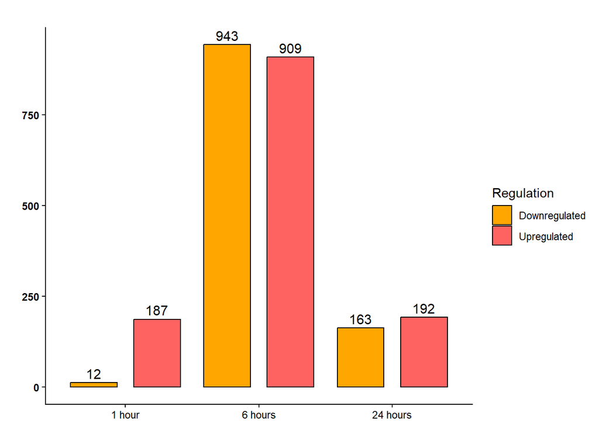

```r
# png(file.path(figures_dir, "DGE_following_IFN_summary.png"), width = 1800, height = 1200, res = 300)
# pdf(file.path(figures_dir, "Barplot_DEGs.pdf"), width = 6, height = 4)


 plot_DE_All_summary(
  All_comparisons,
  "",
  cols = c(27, 28, 29),
  custom_labels = c("1 hour", "6 hours", "24 hours")
)
```

```r
# dev.off()
```

# Temporal difference in IRG expression

Determine whether the genes up-regulated or down regulated following 1 h 6 h and 24 h IFN treatment have similar gene profiles

```r
# source("08_venn.R")
library(ggvenn)
```

## Venn diagram : Overlap of ISGs post 1h, 6h, 24h post IFN treatment -

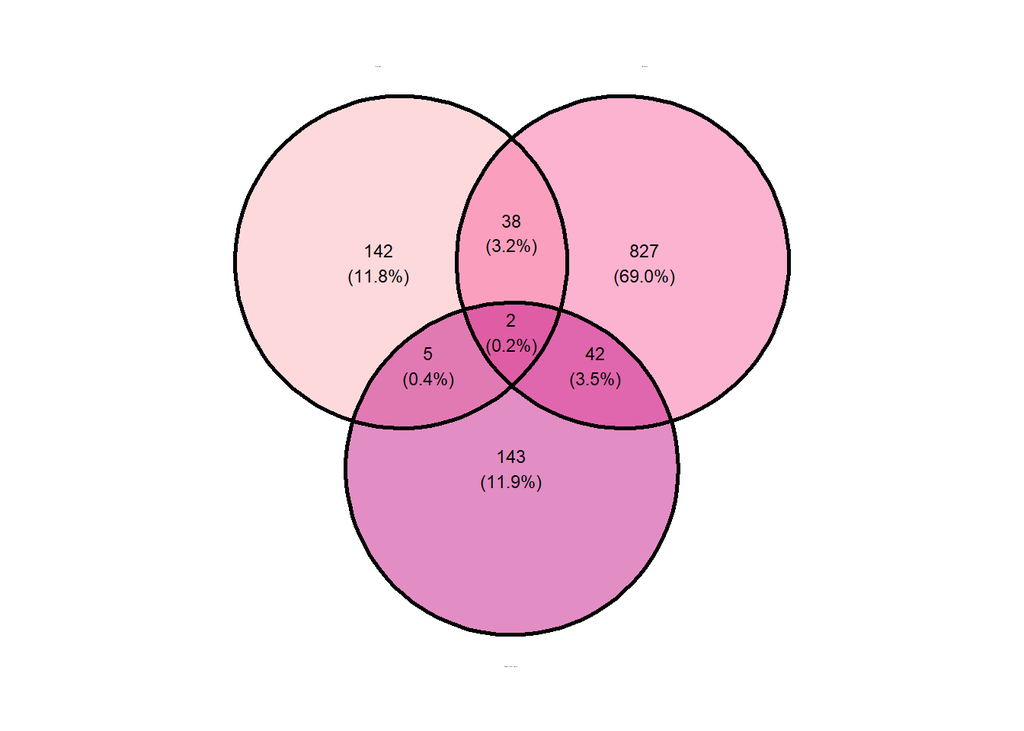

```r
# Prepare the data for ggvenn
venn_data <- list(
  "One Hour" = One_hour[One_hour[, 11] == 1, "SYMBOL"],
  "Six Hours" = Six_hours[Six_hours[, 11] == 1, "SYMBOL"],
  "Twenty Four Hours" = TwentyFour_hours[TwentyFour_hours[, 11] == 1, "SYMBOL"]
)

# Create the Venn diagram using ggvenn
venn_gg <- ggvenn::ggvenn(
  venn_data,
  fill_color = c("#fbb4b9", "#f768a1", "#c51b8a"),
  stroke_size = 1,
  set_name_size = 0,
  text_size = 3
)

# Display the Venn diagram
venn_gg
```

```r
# Assuming venn_gg is your ggvenn plot object
# ggsave(filename = file.path(figures_dir, "VennDiagram_upregulated.png"), plot = # venn_gg,
#       width = 6, height = 6, units = "in", dpi = 300)

# ggsave(filename = file.path(figures_dir, "VennDiagram_upregulated.pdf"), plot = venn_gg,
#       width = 6, height = 6, units = "in")
```

**IFN-Downregulated** genes

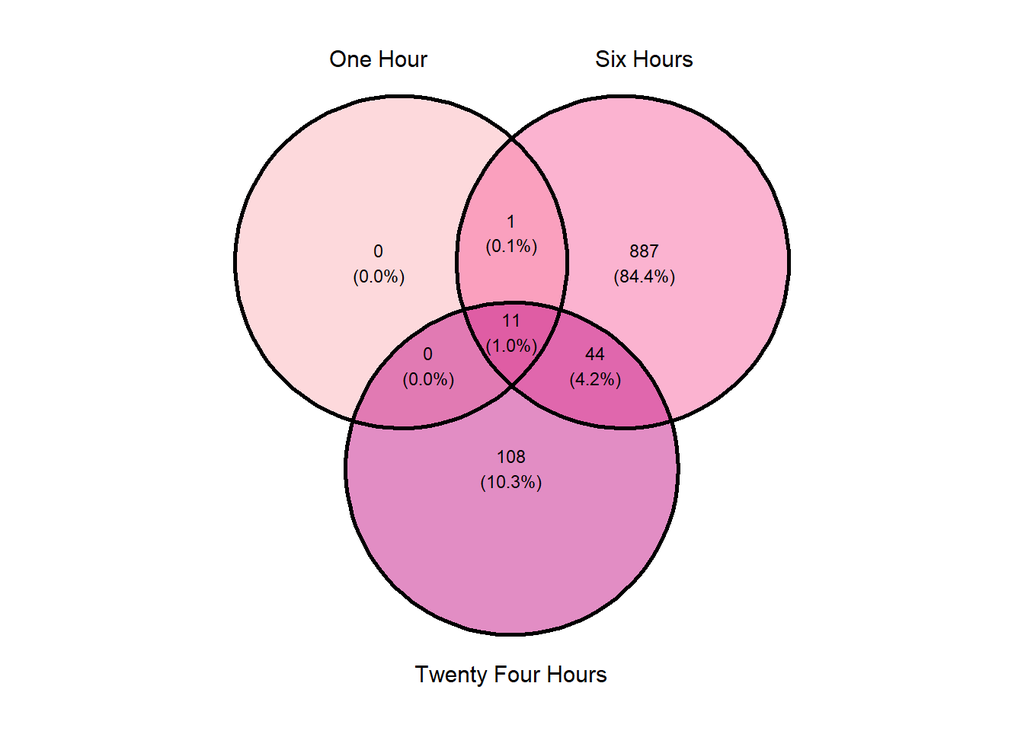

```r
# Prepare the data for ggvenn
venn_data <- list(
  "One Hour" = One_hour[One_hour[, 11] == -1, "SYMBOL"],
  "Six Hours" = Six_hours[Six_hours[, 11] == -1, "SYMBOL"],
  "Twenty Four Hours" = TwentyFour_hours[TwentyFour_hours[, 11] == -1, "SYMBOL"]
)

# Create the Venn diagram using ggvenn
venn_gg_supressed <- ggvenn(
  venn_data,
  fill_color = c("#fbb4b9", "#f768a1", "#c51b8a"),
  stroke_size = 1,
  set_name_size = 4,
  text_size = 3
)

# Display the Venn diagram
venn_gg_supressed
```

```r
# Assuming venn_gg is your ggvenn plot object
ggsave(filename = file.path(figures_dir, "VennDiagram_downregulated.png"), plot = venn_gg_supressed,
       width = 6, height = 6, units = "in", dpi = 300)

ggsave(filename = file.path(figures_dir, "VennDiagram_downregulated.pdf"), plot = venn_gg_supressed,
       width = 6, height = 6, units = "in")
```

```r
detach("package:ggvenn", unload=TRUE)
```

Gene expression profiles of differentially expressed genes following IFN treatment at 0 h, 1 h, 6 h and 24 h time points with and without RABV-P expression

```r
# source("09_heatmap.R")

library(pheatmap)

# heatmap
heat.map.of.interest <- function(data, chosen, subset = TRUE,
                                 scale = "none", cluster_cols = FALSE, scale.max = NULL, labels_row = myDGElist$genes$SYMBOL, pdf_file = NULL,fontsize = 40, fontsize_row = 40, fontsize_col = 40, ...) {

  # Subset the data matrix
  data %<>% `[`(chosen, subset)

  # Set the color palette for the heatmap
  colours <- colorRampPalette(rev(brewer.pal(n = 7, name = "RdYlBu")))(100)

  # Adjust the color breaks if scale.max is provided
  if (!is.null(scale.max)) {
    breaks <- seq(-scale.max, scale.max, length.out = 101)
    colours <- colorRampPalette(rev(brewer.pal(7, "RdBu")))(100)
  } else {
    breaks <- NA
  }

  # Create the annotation data frame
  annotation_col <- data.frame(
    Protein = myDGElist$samples$Protein[subset],
    IFN_Treatment = myDGElist$samples$Time[subset],
    row.names = colnames(data)
  )

  # Set the desired order for the IFN_Treatment factor levels
  desired_order <- c("0hr", "1hr", "6hr", "24hr")  # replace with actual desired order
  annotation_col$IFN_Treatment <- factor(annotation_col$IFN_Treatment, levels = desired_order)

  # Define the annotation colors
  annotation_colors <- list(
    Protein = Protein.cols,
    IFN_Treatment = IFN.Cols[desired_order]
  )


  # Create the heatmap using pheatmap
  data %>%
    pheatmap(
      cluster_rows = TRUE,
      cluster_cols = cluster_cols,
      show_colnames = FALSE,
      annotation_col = annotation_col,
      annotation_colors = annotation_colors,
      border_color = NA,
      breaks = breaks,
      color = colours,
      labels_row = labels_row[chosen],
      scale = scale,
      fontsize = fontsize,           # Adjust overall font size (affects legend)
      fontsize_row = fontsize_row,   # Adjust row label font size
      fontsize_col = fontsize_col,
      ...
    )

}
```

## Heatmap: Global expression patterns of ISGs with RABV-P -

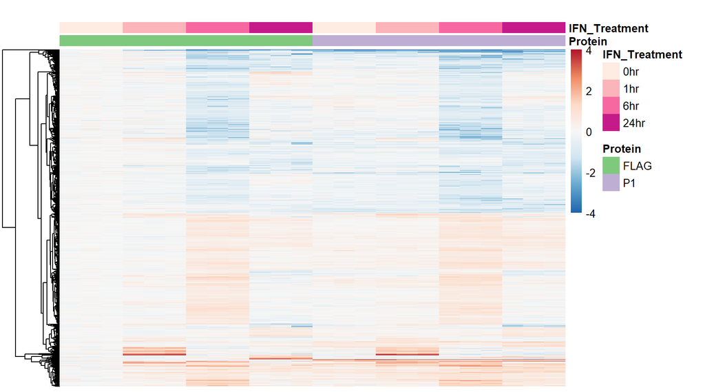

```r
heat.map.of.interest(log2.cpm.filtered.norm.relative,
chosen = apply(results[, contrast.type$v] != 0, 1, any),
subset = order(myDGElist$samples$Protein),
scale.max = 4,
show_rownames = FALSE,
main = "",
fontsize = 10,           # Adjust overall font size (affects legend)
fontsize_row = 10,   # Adjust row label font size
fontsize_col = 10,
)
```

RE ordered by Protein group ( FLAG vs P1 )

```r
detach("package:pheatmap", unload=TRUE)
```

Proportion of Affected genes

```r
# source("12_pie_chart.R")

library(ggrepel)
library(patchwork)


create_pie_chart <- function(dataframe, title, custom_colors, direction = 1) {

  # Filter rows dynamically using the user-supplied osm value
  filtered_data <- dataframe[
    dataframe[, 11] == direction & dataframe$Classification != "Background",
  ]

  # Count classifications
  classification_counts <- as.data.frame(table(filtered_data$Classification))
  colnames(classification_counts) <- c("Classification", "Count")

  # Calculate proportions and label positions
  classification_counts$Proportion <- round((classification_counts$Count / sum(classification_counts$Count)) * 100, 1)

  classification_counts <- classification_counts %>%
    mutate(
      csum = rev(cumsum(rev(Count))),
      pos  = Count / 2 + lead(csum, 1),
      pos  = if_else(is.na(pos), Count / 2, pos)
    )

  # Create pie chart
  pie_chart <- ggplot(classification_counts, aes(x = "", y = Count, fill = Classification)) +
    geom_col(width = 1, color = "white") +
    coord_polar(theta = "y") +
    theme_void() +
    theme(
      plot.title = element_text(hjust = 0.5, size = 10),
      legend.position = "right",
      plot.margin = margin(2, 2, 2, 2)
    ) +
    labs(title = title, fill = "Classification") +
    scale_fill_manual(values = custom_colors) +
    geom_label_repel(
      data = classification_counts,
      aes(y = pos, label = paste0(Proportion, "%")),
      size = 4.5,
      nudge_x = 1,
      show.legend = FALSE
    )

  return(pie_chart)
}

# Define custom colors for classifications
custom_colors <- c("Unaffected" = "grey", "Antagonized" = "#de425b", "Enhanced" = "#488f31")
```

## Pie chart: Proportion of ISGs antagonized/unaffected/Enhanced by RABV-P -

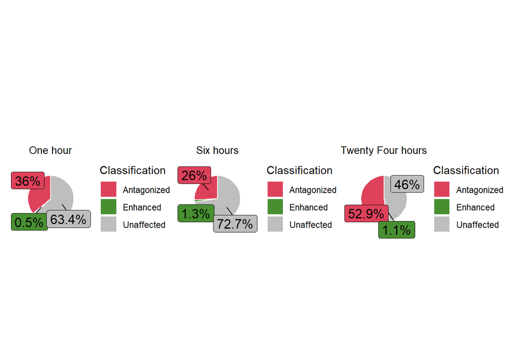

```r
pie_chart_One_hour <- create_pie_chart(One_hour, "One hour", custom_colors, direction = 1)
pie_chart_Six_hours <- create_pie_chart(Six_hours, "Six hours", custom_colors, direction = 1)
pie_chart_TwentyFour_hours <- create_pie_chart(TwentyFour_hours, "Twenty Four hours", custom_colors, direction = 1)

# Assemble the pie charts into a single figure
pie_chart <- pie_chart_One_hour + pie_chart_Six_hours + pie_chart_TwentyFour_hours +
plot_annotation(title = "")

# Display the combined figure
pie_chart
```

```r
#Assuming venn_gg is your ggvenn plot object
# ggsave(filename = file.path(figures_dir, "PieChart_Upregulated.png"), plot = pie_chart,
#       width = 10, height = 6, units = "in", dpi = 300)

ggsave(filename = file.path(figures_dir, "PieChart_Upregulated.pdf"), plot = pie_chart,
       width = 10, height = 6, units = "in")
```

IFN **down-regulated** genes affected by RABV-P

```r
pie_chart_One_hour_down <- create_pie_chart(One_hour, "One hour", custom_colors, direction = -1)
pie_chart_Six_hours_down <- create_pie_chart(Six_hours, "Six hours", custom_colors, direction = -1)
pie_chart_TwentyFour_hours_down <- create_pie_chart(TwentyFour_hours, "Twenty Four hours", custom_colors, direction = -1)

# Assemble the pie charts into a single figure
pie_chart2 <- pie_chart_One_hour_down + pie_chart_Six_hours_down + pie_chart_TwentyFour_hours_down +
plot_annotation(title = "")

# Display the combined figure
# pie_chart2

#Assuming venn_gg is your ggvenn plot object
# ggsave(filename = file.path(figures_dir, "PieChart_downregulated.png"), plot = pie_chart2,
  #     width = 10, height = 6, units = "in", dpi = 300)

ggsave(filename = file.path(figures_dir, "PieChart_downregulated.pdf"), plot = pie_chart2,
       width = 10, height = 6, units = "in")
```

```r
# source("13_parallel.R")

library(GGally)
library(ggplotify)
create_parallel_plot <- function(dataframe, title, custom_colors, direction = 1) {

  # Filter based on direction (1 = induced, -1 = suppressed)
  filtered_data <- dataframe[dataframe[, 11] == direction &
                               dataframe$Classification != "Background", ]

  # Rename columns for better display
  colnames(filtered_data)[5] <- "FLAG + IFN"
  colnames(filtered_data)[6] <- "IFN + P1"

  # Add a baseline control column
  filtered_data$Control <- 0

  # Build parallel coordinate plot
  ggparcoord(data = filtered_data,
             columns = c(ncol(filtered_data), 5, 6),  # Control, FLAG+IFN, IFN+P1
             groupColumn = "Classification",
             alphaLines = 1,
             scale = "globalminmax",
             showPoints = TRUE) +
    geom_point(aes(text = SYMBOL), size = 3) +
    theme_bw() +
    labs(title = title, x = "", y = "Log2Fold Change") +
    scale_color_manual(values = custom_colors) +
    theme(
      text = element_text(size = 14),
      axis.text = element_text(size = 8, face = "bold"),
      axis.title = element_text(size = 8, face = "bold"),
      plot.title = element_text(size = 8, face = "bold"),
      legend.text = element_text(size = 8),
      legend.title = element_text(size = 8),
      legend.position = "none",
      aspect.ratio = 0.9
    )
}
```

IFN **up-regulated** genes

```r
parallel_plot_One_hour_up <- create_parallel_plot(One_hour, "One Hour", custom_colors, direction = 1)
parallel_plot_Six_hours_up <- create_parallel_plot(Six_hours, "Six Hours", custom_colors, direction = 1)
parallel_plot_TwentyFour_hours_up <- create_parallel_plot(TwentyFour_hours, "Twenty Four hours", custom_colors, direction = 1)
```

IFN **down-regulated** genes

```r
parallel_plot_One_hour_down <- create_parallel_plot(One_hour, "One Hour", custom_colors, direction = -1)
parallel_plot_Six_hours_down <- create_parallel_plot(Six_hours, "Six Hours", custom_colors, direction = -1)
parallel_plot_TwentyFour_hours_down <- create_parallel_plot(TwentyFour_hours, "Twenty four Hours", custom_colors, direction = -1)
```

## Parallel coordinate plot : RABV-P affected/unaffected/Enhanced ISGs -

```r
combined_plot <- parallel_plot_One_hour_up + parallel_plot_Six_hours_up + parallel_plot_TwentyFour_hours_up +
parallel_plot_One_hour_down + parallel_plot_Six_hours_down + parallel_plot_TwentyFour_hours_down +
plot_layout(ncol = 3)

ggsave(filename = file.path(figures_dir, "combined_parallel_plots.pdf"),
       plot = combined_plot,
       width = 12,
       height = 8)
```

All the component for **Figure 1** are produced and exported as Pdf to be edited using *affinity designer*

## Volcano plot: Differentially expressed ISGs

```r
library(EnhancedVolcano)
```

At 1 h ,6h and 24 h post IFN treatment respectively

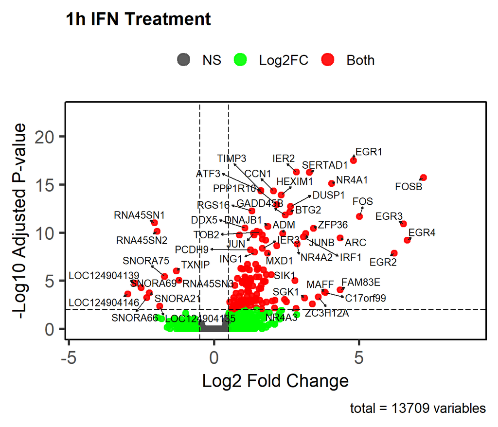

```r
 # volcano1 <-
  EnhancedVolcano(
  One_hour,
  lab = One_hour$SYMBOL,
  x = 'FLAG_1hr.v.FLAG_0hr.logFC',
  y = 'FLAG_1hr.v.FLAG_0hr.adj.P.Val',
  title = '1h IFN Treatment',
  subtitle = NULL,
  xlab = 'Log2 Fold Change',
  ylab = '-Log10 Adjusted P-value',
  pCutoff = 0.01,
  FCcutoff = 0.5,
  pointSize = 2.0,
  labSize = 3.5,
  col = c('grey30', 'green', '#BE684D', 'red'),  # NS, down, up, both
  colAlpha = 0.9,
  drawConnectors = TRUE,
  max.overlaps = 20,
  legendLabels = c('NS', 'Log2FC', 'Adjusted p-value', 'Both'),
  legendPosition = 'top',
  border = 'full',
  gridlines.major = FALSE,
  gridlines.minor = FALSE,
  boxedLabels = FALSE
)
```

```r
# ggsave(
#  filename = file.path(figures_dir, "Volcano_plot_1h.pdf"),
#  plot = volcano1,
#  device = cairo_pdf,   # ensures proper font embedding
#  width = 7,            # inches (PNAS 2-column width)
#  height = 7,           # adjust as needed
#  units = "in"
# )
```

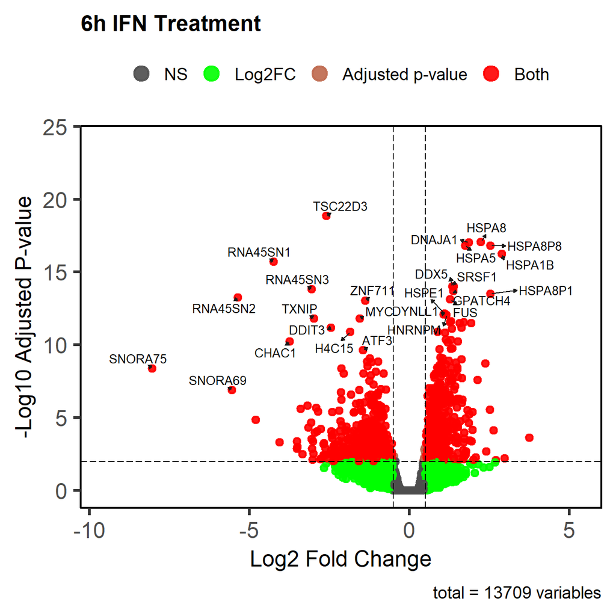

```r
# volcano2 <-
EnhancedVolcano(
  Six_hours,
  lab = Six_hours$SYMBOL,
  x = 'FLAG_6hr.v.FLAG_0hr.logFC',
  y = 'FLAG_6hr.v.FLAG_0hr.adj.P.Val',
  title = '6h IFN Treatment',
  subtitle = NULL,
  xlab = 'Log2 Fold Change',
  ylab = '-Log10 Adjusted P-value',
  pCutoff = 0.01,
  FCcutoff = 0.5,
  pointSize = 2.0,
  labSize = 3.5,
  col = c('grey30', 'green', '#BE684D', 'red'),  # NS, down, up, both
  colAlpha = 0.9,
  drawConnectors = TRUE,
  max.overlaps = 20,
  legendLabels = c('NS', 'Log2FC', 'Adjusted p-value', 'Both'),
  legendPosition = 'top',
  border = 'full',
  gridlines.major = FALSE,
  gridlines.minor = FALSE,
  boxedLabels = FALSE
)
```

```r
#ggsave(
#  filename = file.path(figures_dir, "Volcano_plot_6h.pdf"),
#  plot = volcano2,
#  device = cairo_pdf,   # ensures proper font embedding
#  width = 7,            # inches (PNAS 2-column width)
#  height = 7,           # adjust as needed
#  units = "in"
# )
```

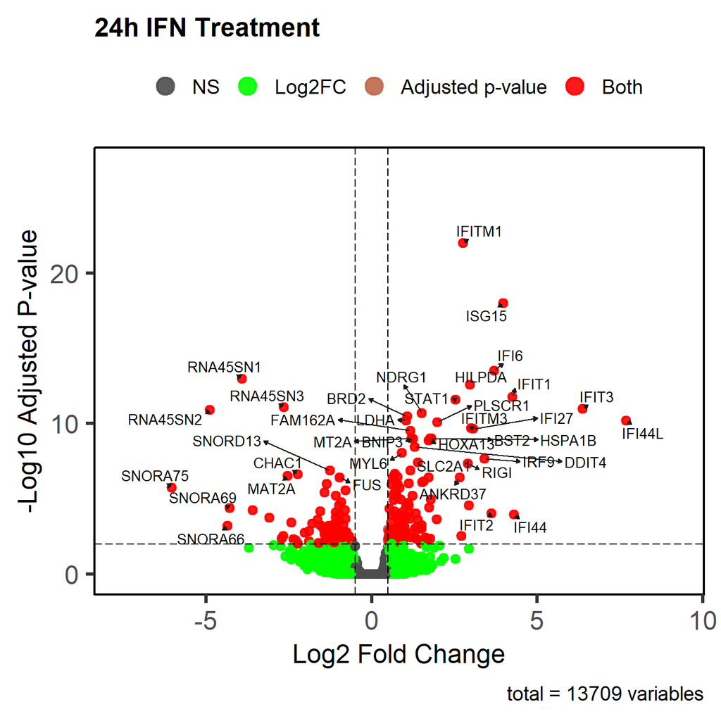

```r
# volcano3 <-
  EnhancedVolcano(
  TwentyFour_hours,
  lab = TwentyFour_hours$SYMBOL,
  x = 'FLAG_24hr.v.FLAG_0hr.logFC',
  y = 'FLAG_24hr.v.FLAG_0hr.adj.P.Val',
  title = '24h IFN Treatment',
  subtitle = NULL,
  xlab = 'Log2 Fold Change',
  ylab = '-Log10 Adjusted P-value',
  pCutoff = 0.01,
  FCcutoff = 0.5,
  pointSize = 2.0,
  labSize = 3.5,
  col = c('grey30', 'green', '#BE684D', 'red'),  # NS, down, up, both
  colAlpha = 0.9,
  drawConnectors = TRUE,
  max.overlaps = 20,
  legendLabels = c('NS', 'Log2FC', 'Adjusted p-value', 'Both'),
  legendPosition = 'top',
  border = 'full',
  gridlines.major = FALSE,
  gridlines.minor = FALSE,
  boxedLabels = FALSE # set to true for bozed labels which makes figure look better but takes up SPACE
)
```

```r
#ggsave(
#  filename = file.path(figures_dir, "Volcano_plot_24h.pdf"),
#  plot = volcano3,
#  device = cairo_pdf,   # ensures proper font embedding
#  width = 7,            # inches (PNAS 2-column width)
#  height = 7,           # adjust as needed
#  units = "in"
# )
```

# Functional annotation and enrichment analysis

```r
msigdb.gsets <- c("h", "c2", "c3", "c5", "c7")

msigdb.descriptions <- c("Hallmark gene sets",
                         "Curated gene sets",
                         "Motif gene sets",
                         "GO gene sets",
                         "immunologic gene sets")
names(msigdb.descriptions) <- msigdb.gsets

kegg.exclude <- "all"
```

Here **$gs_collection** and **$gs_subcollection`** replace **&gs_cat** and **$gs_subcat** **collection$ncbi_gene** replaces **collection$entrez_gene**

```r
library(msigdbr)

msigdb.Hs <- msigdbr(species = "Homo sapiens")

msigdb.Hs.split <- msigdb.Hs %>%
    split(f = paste(.$gs_collection, .$gs_subcollection, sep = "_")) %>%
    set_names(sub("_$", "", names(.)))

names(msigdb.Hs.split)[names(msigdb.Hs.split) %in% c("C5_BP", "C5_CC", "C5_MF")] %<>% sub(pattern = "C5_", replacement = "C5_GO:")


# c("C1",
# "C2_CGP", "C2_CP", "C2_CP:BIOCARTA", "C2_CP:KEGG", "C2_CP:PID", "C2_CP:REACTOME",
# "C3_MIR:MIR_Legacy", "C3_MIR:MIRDB", "C3_TFT:GTRD", "C3_TFT:TFT_Legacy",
# "C4_CGN", "C4_CM",
# "C5_BP", "C5_CC", "C5_MF",
# "C6", "C7", "H")

msigdb.Hs.lists <- lapply(msigdb.Hs.split, function(collection) split(x = collection$ncbi_gene, f = collection$gs_name))

min.size <- 5

msigdb.index.lists <- lapply(msigdb.Hs.lists, function(collection){
                            lapply(collection, function(gs) which(myDGEList.norm$genes$ENTREZID %in% gs)) %>% `[`(lengths(.) >= min.size)
                        })
```

```r
collections <-   names(msigdb.index.lists) #  c("H", "C2_CP:REACTOME", "C5_BP", "C3_TFT:GTRD", "C7") #
 camera.results <- list()

# collections <- c("h", "c2.REACTOME", "c5.BP", "c3", "c7") # names(gs.annots)
 y.disp <- estimateDisp(myDGEList.norm, design, robust = TRUE)
 camera.results <- list()
  for(contrast in colnames(cont.matrix)){
    camera.results[[contrast]] <- lapply(collections, function(gs){

      camera.run <- cameraPR(fit2.eBayes$t[, contrast], msigdb.index.lists[[gs]], sort = FALSE)  %>% # camera(y.disp, msigdb.index.lists[[gs]], design, cont.matrix[,contrast], sort = FALSE) %>% #
       transform(
        score = sign(as.numeric(factor(Direction)) - 1.5) * -log10(FDR),
        avg.logFC = sapply(msigdb.index.lists[[gs]], function(x) mean(fit2$coefficients[x, contrast]))
      )

    if(gs %in% c("H", "C2_CP:REACTOME", "C5_GO:BP", "C3_TFT:GTRD", "C3_TFT:TFT_Legacy")){

      signed.rank.matrix <- rank(fit2$p.value[, contrast]) * unclass(results)[, contrast]

      camera.run %<>% transform(sig.Genes = t(sapply(msigdb.index.lists[[gs]], function(x){
        sr <- signed.rank.matrix[x]
        gs.genes <- as.character(myDGEList.norm$genes$SYMBOL[x])[sr != 0]
        sr %<>% magrittr::extract(. != 0)

        # Gene symbols ordered by P-value
        significant.genes <- gs.genes[order(abs(sr))]

        # Separate into significantly up and down gene symbols ordered by P-value
        significant.up <- unique(significant.genes[sr[order(abs(sr))] > 0])
        significant.down <- unique(significant.genes[sr[order(abs(sr))] < 0])
        significant.genes %<>% unique

        # Trim the top overall significant.genes for display purposes
        if(length(significant.genes) > 5){
          significant.genes <- c(head(significant.genes, 5), "...")
        }
        # Return the resulting genes
        c(
          Top = paste(significant.genes, collapse = ";"),
          Up = paste(significant.up, collapse = ";"),
          Down = paste(significant.down, collapse = ";")
        )
      })))

    }

      camera.run

    }) %>% set_names(collections)
  }
```

```r
types <- list(
  One_hour = contrast.type$Comparison_1hr,
  Six_hours = contrast.type$Comparison_6hr,
  TwentyFour_hours = contrast.type$Comparison_24hr
)

for(collection in c("H", "C2_CP:REACTOME", "C5_GO:BP", "C3_TFT:GTRD", "C3_TFT:TFT_Legacy")){
  camera.cols <- c("avg.logFC", "PValue", "FDR", "Results", "sig.Genes.Up", "sig.Genes.Down")

  wb <- createWorkbook()
  round.style <- createStyle(numFmt = "0.000")
  p.style <- createStyle(numFmt = "SCIENTIFIC")

  gs.names <- names(msigdb.index.lists[[collection]])

  camera.write.list <- lapply(camera.results, function(x){
    if("Direction" %in% colnames(x[[collection]])) {
      x[[collection]] %>%
        transform(Results = ifelse(Direction == "Up", 1, -1) * (FDR < 0.05)) %>%
        `[`(gs.names, )
    } else {
      warning(paste("'Direction' column not found in collection:", collection))
      NULL
    }
  })

  for(type.name in names(types)){
    ct <- types[[type.name]]
    camera.merge <-  do.call(what = "cbind", lapply(camera.write.list[ct], "[", , camera.cols)) %>% `[`(, order(rep(1:length(camera.cols), length.out = ncol(.))))
    camera.merge <- cbind(
                          Set.Size = lengths(msigdb.Hs.lists[[collection]][gs.names]),
                          Genes.Expressed = lengths(msigdb.index.lists[[collection]][gs.names]),
                          camera.merge)
    addWorksheet(wb, type.name)

    Gene.Set <- c("https://www.gsea-msigdb.org/gsea/msigdb/index.jsp", paste0("https://www.gsea-msigdb.org/gsea/msigdb/cards/", gs.names, ".html"))
    names(Gene.Set) <- c("MSigDB.Gene.Set", gs.names)
    class(Gene.Set) <- "hyperlink"

    final.columns <- c(names(Gene.Set)[1], colnames(camera.merge))
    writeData(wb, sheet = type.name, x = Gene.Set, startCol = 1)
    writeData(wb, type.name, camera.merge, colNames = TRUE, startCol = 2) #, withFilter = TRUE)

    addStyle(wb, type.name, createStyle(textDecoration = "bold"), rows = 1, cols = 1:length(final.columns))
    non.header <- 1 + 1:length(gs.names)

    conditionalFormatting(wb, type.name, cols = grep("Set.Size|Genes.Expressed", final.columns), rows = non.header,
                          style = (RColorBrewer::brewer.pal(3, "Greens")), type = "colourScale")

    max.abs <- 1 # max(abs(camera.merge[, c(grep("logFC", colnames(camera.merge)))]))

    for(i in grep("logFC", final.columns)){
      conditionalFormatting(wb, type.name, cols = i, rows = non.header,
                            style = rev(RColorBrewer::brewer.pal(3, "RdBu")),
                            rule = max.abs * (-1:1),
                            type = "colourScale")
      addStyle(wb, type.name, style = round.style, cols = i, rows = non.header, stack = TRUE)
    }

    conditionalFormatting(wb, type.name, cols = grep("Results", final.columns), rows = non.header, rule = -1:1,
                          style = rev(RColorBrewer::brewer.pal(3, "RdBu")), type = "colourScale")

    for(i in grep("P\\.*Val|FDR", final.columns)){
      conditionalFormatting(wb, type.name, cols = i, rows = non.header, rule = "<0.05",
                            style = createStyle(bgFill = brewer.pal(4, "Pastel2")[4]), type = "expression")
      addStyle(wb, type.name, style = p.style, cols = i, rows = non.header, stack = TRUE)
    }

  }
    saveWorkbook(wb,
                 file.path(
                 tables_dir,
                 paste("Reworking_camera", make.names(collection),
                       "gene_set_tests.xlsx", sep = "_")),
                 overwrite = TRUE)
  }

rm(wb, camera.write.list, camera.merge)
```

```r
## Display some of these results
## Table
# Function to get the top n gene sets from the camera results
# Order by rank column; reverse if direction = -1
topCamera <- function(results, set, contrast, n = 5, rank = "PValue", direction = 1, up.down = "Both"){
  data <- results[[contrast]][[set]] %>% magrittr::extract(order(direction*magrittr::extract(.,,rank)), !(colnames(.) %in% c("score", "sig.Genes.Up", "sig.Genes.Down"))) %>% `[`(up.down == "Both" | .$Direction == up.down,) %>% head(n = n)
  return(data)
}

#topCamera("h", 1) ## 1 = results of first contrast in contrasts

#kable(topCamera("h", 1), digits = c(0, 0, 50, 50, 3, 0))


## Bar plot function

## Bar plot function
topBarPlot <- function(results, set, contrast, n = 25, rank = "PValue", direction = 1, up.down = "Both",
                       fdr.cutoff = 0.05, hide.insignificant = FALSE, logFC.max = 2,
                       both.lim = T, both.width = T, xlim.scale = (4/3), n.mid = 45, n.long = 65,
                       left.mar = 17,
                       top.up.and.down = F,
                       main = NULL, legend.position = "bottomright", ...){

  # Get the top results and reverse order, so that most significant genes sets will be at the top on the plot
  data <- topCamera(results, set, contrast, n, rank, direction, up.down) %>% magrittr::extract(nrow(.):1, )

  if(up.down == "Both" & top.up.and.down){
    data <- topCamera(results, set, contrast, n, rank, direction, up.down = "Down") %>% magrittr::extract(nrow(.):1, )
    data %<>% rbind(topCamera(results, set, contrast, n, rank, direction, up.down = "Up")  %>% magrittr::extract(nrow(.):1, ))
  }


  # If hide.insignificant, remove those less than the suppled FDR cut-off
  if(!is.na(fdr.cutoff) & hide.insignificant){
    data <- data[data$FDR < fdr.cutoff,]
  }

  # If there is any data left to plot
  if(!is.na(fdr.cutoff) & sum(data$FDR < fdr.cutoff) > 0){

    # Adjust margins, extra long on the left (second position), to accommodate gene set labels
    # Could adjust this
    par(mar=c(4, left.mar, 4, 2) + 0.1)

    ## Make a colour scale going from -logFC.max to logFC.max by steps of 0.1
    if(logFC.max < 0.1){
      logFC.max <- 0.1
    }
    sequence <- seq(0.1, logFC.max, 0.1)
    colour.scale <- colorRampPalette(rev(brewer.pal(11,"RdYlBu")))(2*length(sequence))
    # Replace values outside the range with the max (or negative max)
    avg.logFC <- data$avg.logFC %>% pmin(logFC.max) %>% pmax(-logFC.max)
    # Replace values with colours by cutting the values into bins defined by breaks
    # Include lowest to capture any avg.logFC == -logFC.max
    avg.logFC.col <- cut(avg.logFC, breaks = c(-rev(sequence), 0, sequence), labels = colour.scale, include.lowest = TRUE)

    xlim <- c(0, xlim.scale * max(-log10(data$FDR)))
    if(up.down != "Both"){
      xlim <- c(0, xlim.scale * -log10(topCamera(results, set, contrast, n=1)$FDR))
    }

    ## Basic R barplot function
    # Plot barcode and store positions of all bars
    positions <- barplot(
      # bar length is -log10(FDR)
      -log10(data$FDR),
      # Width is relative gene set size
      # Maybe this should be scaled better
      width = data$NGenes,
      # expression for making nicely formatted axis label
      xlab = expression("\U2212log"[10]*"(adjusted "*italic(p)*"-value)"),
      # Rotate bar plot and
      horiz = TRUE,
      col = as.character(avg.logFC.col),
      # Set x-axis limits to be slightly more than the longest bar, so a legend can be accommodated
      # Could adjust this
      xlim = xlim,
      # Any other supplied graphical parameter arguments passed
      ...
    )

    # Add labels afterwards
    # Attempt to scale gene set label sizes so they fit on the plot properly
    # This is not ideal
    # May need to adjust some of these numbers

    # Choose some size
    # Number of characters for mid-length and long labels

    # Minimum ratio of gene set size to the sum of the gene set sizes
    size.min <- 0.01

    # Start with a common size value
    cex.names <- rep(0.75, nrow(data))
    # Make smaller labels
    cex.names[nchar(rownames(data)) > n.mid] <- 0.55
    cex.names[data$number/sum(data$number) < size.min] <- 0.55
    cex.names[nchar(rownames(data)) > n.long] <- 0.45

    # Gene set names are stored in row names
    labels <- rownames(data)

    # For long labels, find the middle underscore character in the label and insert a new line character
    labels[nchar(rownames(data)) > n.long] %<>% sapply(function(long.label){
      middle.underscore <- gregexpr("_",long.label) %>% unlist %>% magrittr::extract(ceiling(length(.)/2))
      paste(substr(long.label, 1, middle.underscore), substr(long.label, middle.underscore + 1, nchar(long.label)), sep = "\n")
    })

    # Add labels next to the bars
    mtext(labels,
          # Left hand side = 2
          side = 2,
          # Make sure the labels are horizontal
          las = 1,
          # Use saved bar positions
          at = positions,
          # Offset labels slightly from bars
          line = 0.2,
          # Use appropriate label sizes
          cex = cex.names
    )

    # Title of the plot
    if(is.null(main)){
      main <- paste(set, contrast)
    }
    title(main = main)

    # Add an optional dashed line at the FDR cut-off
    if(!is.na(fdr.cutoff) & !hide.insignificant){
      abline(v = -log10(fdr.cutoff), lty = 2, lwd = 1.5)
    }

    if(!is.null(legend.position)){

      legend(legend.position,
             # Legend title
             title = "avg logFC",
             # Legend values
             legend = c(paste("≥", logFC.max), paste(">", logFC.max*c(0.5, 0.25)), paste("<", -logFC.max*c(0.25, 0.5)), paste("≤", -logFC.max)),
             # Square with border symbol
             pch = 22,
             # Border colour
             col = "black",
             # Fill colour
             pt.bg = colour.scale[c(length(colour.scale), match(as.character(logFC.max*c(0.5, 0.25, -0.25, -0.5, -1)), c(-rev(sequence), 0, sequence)))],
             # Symbol size
             pt.cex = 1.5
      )
    }
  }
}
```

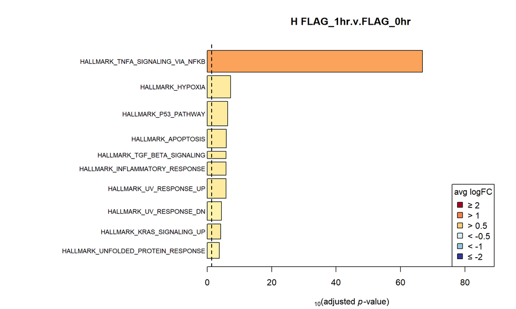

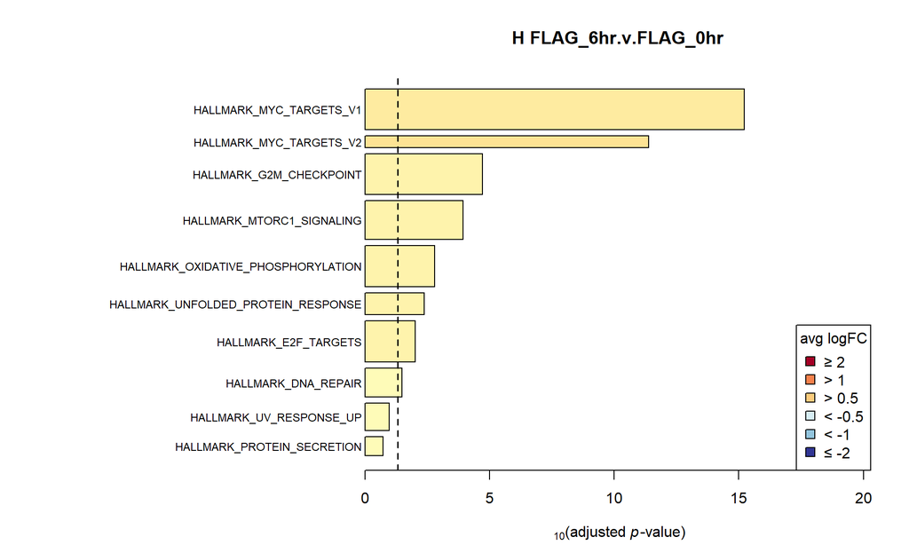

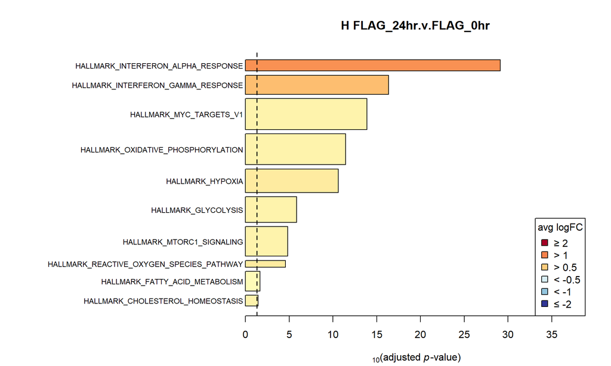

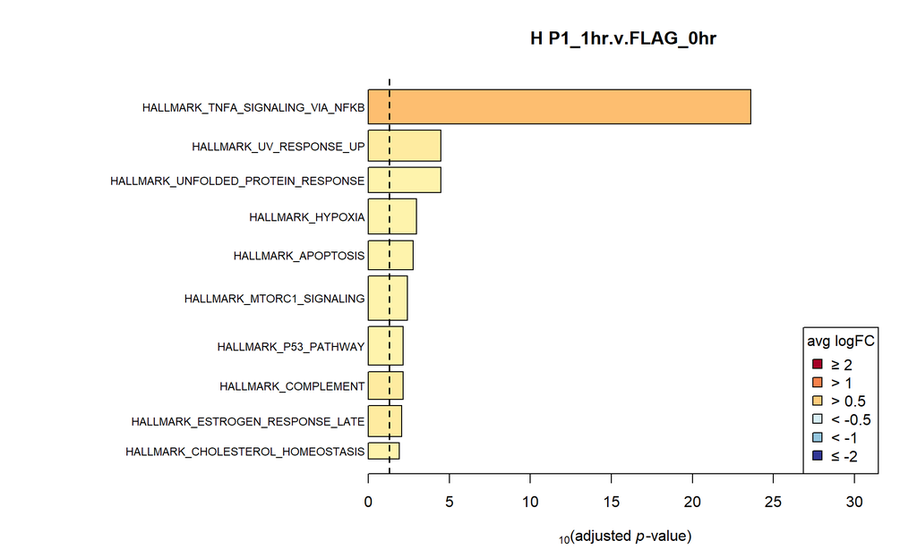

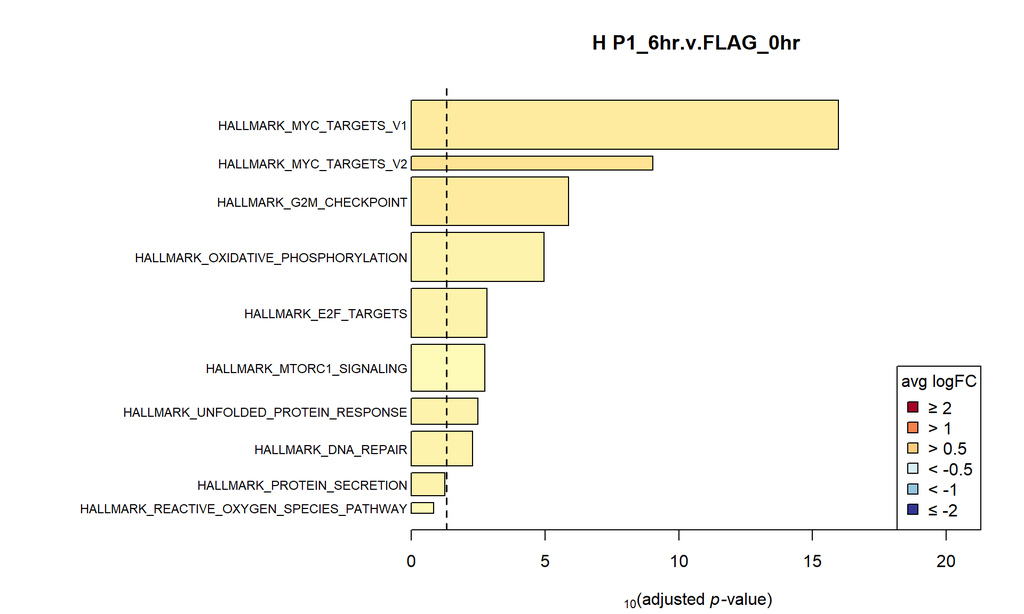

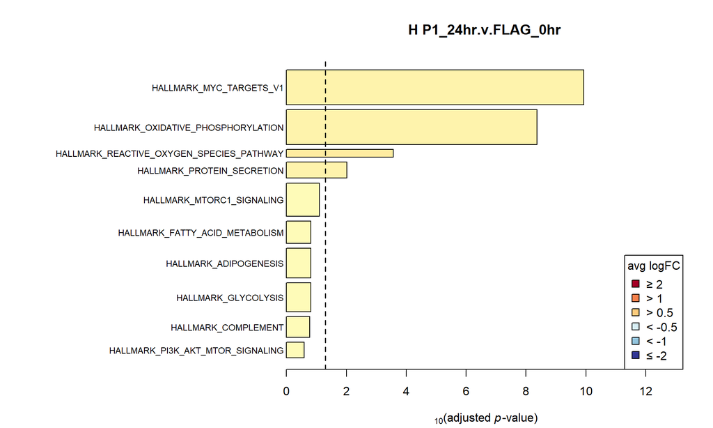

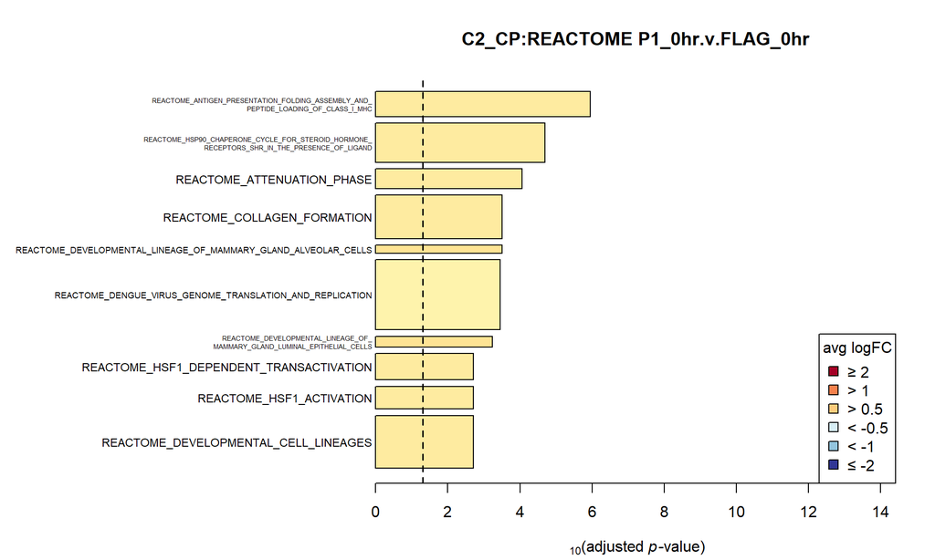

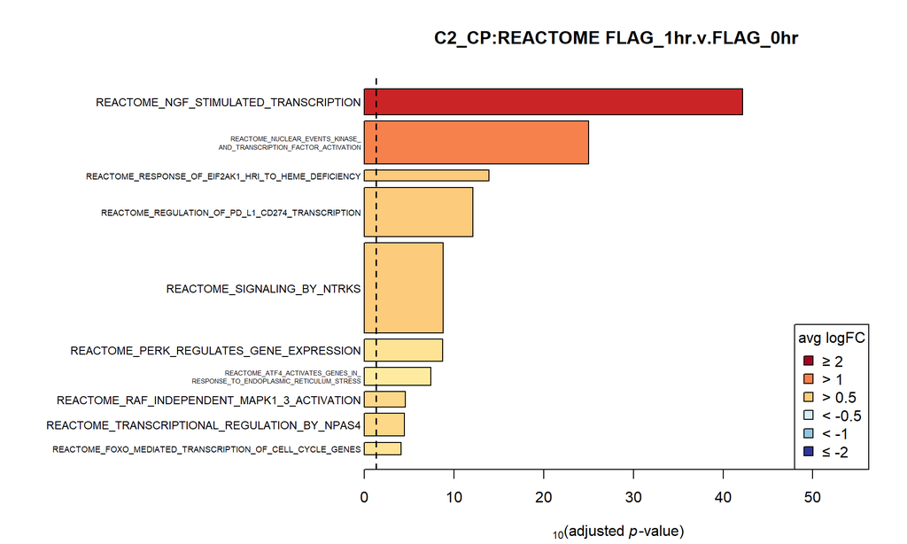

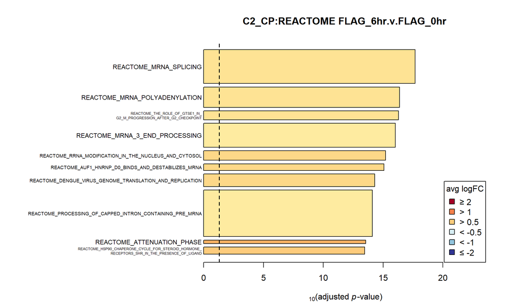

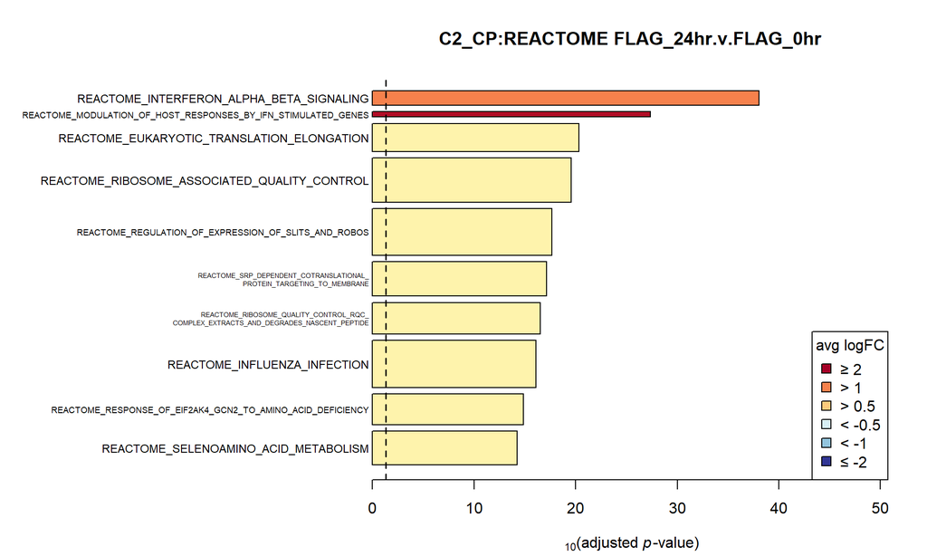

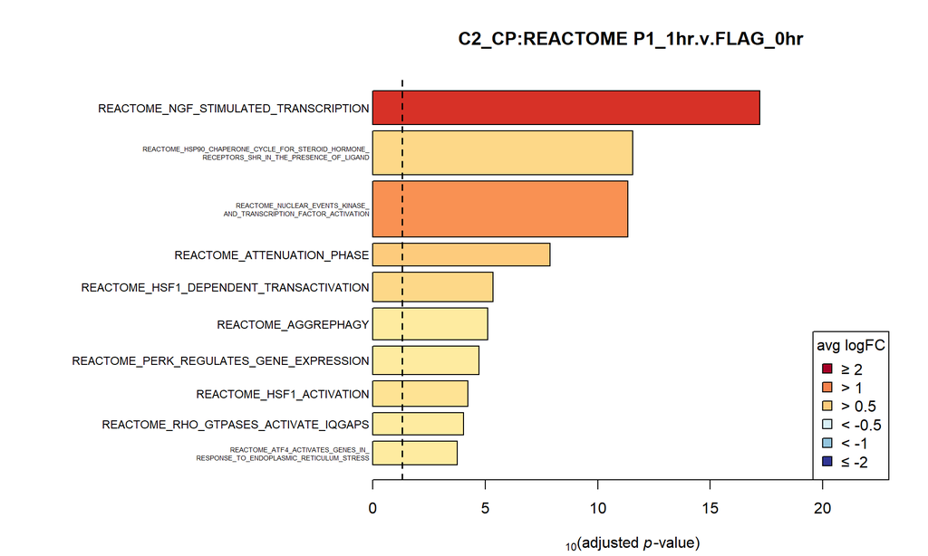

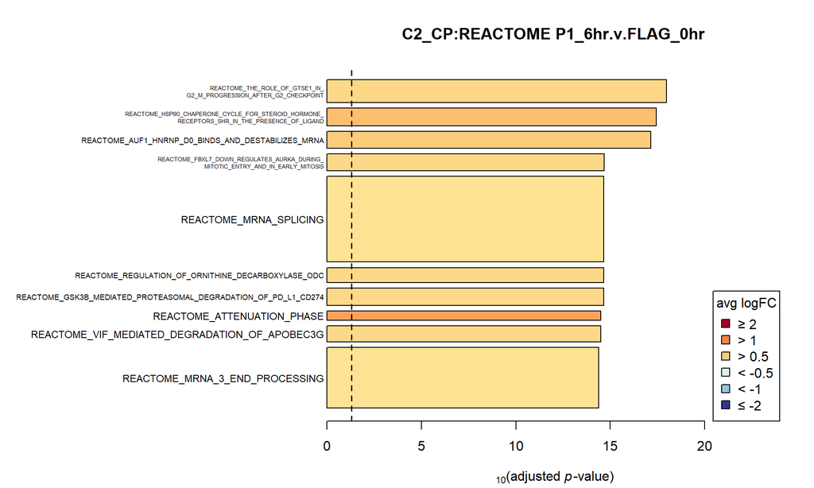

[8 more figures not shown]

```r
# pdf(file.path(figures_dir, "GSEA_barplots_pathway_enrichment_plots.pdf"), width = 12, height = 8)  # Adjust width and height as needed
for(set in c("H", "C2_CP:REACTOME", "C5_GO:BP")){ # names(msigdb.index.lists)
  for(contrast in colnames(cont.matrix)[contrast.type$v]){
      topBarPlot(camera.results, set, contrast, n = 10,up.down = "Up" ,main = paste(set, contrast), left.mar = 20)
  }
}
```

```r
# dev.off()
```

### Barplots : IFN activated pathways antagonized/unaffected by RABV-P- Figure 2A-C

```r
# library(dplyr)
# library(RColorBrewer)
# library(magrittr)

# Get top n gene sets from a camera result table
topCamera <- function(results, set, contrast, n = 5, rank = "PValue", direction = 1, up.down = "Both") {
  data <- results[[contrast]][[set]] %>%
    magrittr::extract(
      order(direction * magrittr::extract(., , rank)),
      !(colnames(.) %in% c("score", "sig.Genes.Up", "sig.Genes.Down"))
    ) %>%
    `[`(up.down == "Both" | .$Direction == up.down, ) %>%
    head(n = n)

  data
}

# Build union of top n gene sets from two contrasts
# FLAG determines the order; P1 follows that order
unionTopCamera <- function(results,
                           set = "H",
                           contrast1,
                           contrast2,
                           n = 10,
                           rank = "PValue",
                           direction = 1,
                           up.down = "Up") {

  top1 <- topCamera(results, set, contrast1, n = n, rank = rank, direction = direction, up.down = up.down)
  top2 <- topCamera(results, set, contrast2, n = n, rank = rank, direction = direction, up.down = up.down)

  union_sets <- unique(c(rownames(top1), rownames(top2)))

  # Full tables for each contrast
  df1 <- results[[contrast1]][[set]][union_sets, , drop = FALSE]
  df2 <- results[[contrast2]][[set]][union_sets, , drop = FALSE]

  # Add pathway names as column
  df1 <- data.frame(pathway = rownames(df1), df1, row.names = NULL, check.names = FALSE)
  df2 <- data.frame(pathway = rownames(df2), df2, row.names = NULL, check.names = FALSE)

  # Remove any accidental duplicates
  df1 <- df1[!duplicated(df1$pathway), , drop = FALSE]
  df2 <- df2[!duplicated(df2$pathway), , drop = FALSE]

  # Sort df1 (FLAG) by significance (lowest FDR = most significant)
  df1 <- df1[order(df1$FDR, na.last = TRUE), , drop = FALSE]

  # Match df2 (P1) to the exact same pathway order as df1
  # This ensures P1 follows FLAG ordering for direct comparison
  pathway_order <- df1$pathway
  df2 <- df2[match(pathway_order, df2$pathway), , drop = FALSE]

  # Keep only rows that matched
  keep <- !is.na(df2$pathway)
  df1 <- df1[keep, , drop = FALSE]
  df2 <- df2[keep, , drop = FALSE]

  # Set row names for plotting
  rownames(df1) <- make.unique(df1$pathway)
  rownames(df2) <- rownames(df1)

  list(flag = df1, p1 = df2)
}

# Plot one barplot panel
plot_union_bar <- function(data,
                           main = NULL,
                           fdr.cutoff = 0.05,
                           hide.insignificant = FALSE,
                           logFC.max = 2,
                           xlim.scale = 4 / 3,
                           left.mar = 20,
                           n.mid = 45,
                           n.long = 65,
                           ...) {

  if (nrow(data) == 0) {
    message("No gene sets to plot.")
    return(invisible(NULL))
  }

  if (!is.na(fdr.cutoff) && hide.insignificant) {
    data <- data[data$FDR < fdr.cutoff, , drop = FALSE]
  }

  if (nrow(data) == 0) {
    message("No gene sets remain after filtering.")
    return(invisible(NULL))
  }

  # Reverse the order so the most significant pathway appears at the top of the barplot
  data <- data[nrow(data):1, , drop = FALSE]

  par(mar = c(4, left.mar, 4, 2) + 0.1)

  if (logFC.max < 0.1) {
    logFC.max <- 0.1
  }

  sequence <- seq(0.1, logFC.max, 0.1)
  colour.scale <- colorRampPalette(rev(brewer.pal(11, "RdYlBu")))(2 * length(sequence))

  avg.logFC <- data$avg.logFC %>% pmin(logFC.max) %>% pmax(-logFC.max)
  avg.logFC.col <- cut(
    avg.logFC,
    breaks = c(-rev(sequence), 0, sequence),
    labels = colour.scale,
    include.lowest = TRUE
  )

  xlim <- c(0, xlim.scale * max(-log10(data$FDR), na.rm = TRUE))
  if (!is.na(fdr.cutoff) && !hide.insignificant) {
    xlim <- c(0, max(xlim[2], xlim.scale * -log10(fdr.cutoff)))
  }

  widths <- if ("NGenes" %in% colnames(data)) {
    data$NGenes
  } else if ("number" %in% colnames(data)) {
    data$number
  } else {
    rep(1, nrow(data))
  }

  positions <- barplot(
    -log10(data$FDR),
    width = widths,
    xlab = expression(-log[10] * "(adjusted " * italic(p) * "-value)"),
    horiz = TRUE,
    col = as.character(avg.logFC.col),
    xlim = xlim,
    ...
  )

  labels <- data$pathway

  cex.names <- rep(0.75, nrow(data))
  cex.names[nchar(labels) > n.mid] <- 0.55
  if ("number" %in% colnames(data)) {
    cex.names[data$number / sum(data$number) < 0.01] <- 0.55
  }
  cex.names[nchar(labels) > n.long] <- 0.45

  long_idx <- nchar(labels) > n.long
  if (any(long_idx)) {
    labels[long_idx] <- sapply(labels[long_idx], function(long.label) {
      underscore_pos <- gregexpr("_", long.label)[[1]]
      if (length(underscore_pos) == 1 && underscore_pos[1] == -1) {
        return(long.label)
      }
      mid_pos <- underscore_pos[ceiling(length(underscore_pos) / 2)]
      paste(
        substr(long.label, 1, mid_pos),
        substr(long.label, mid_pos + 1, nchar(long.label)),
        sep = "\n"
      )
    })
  }

  mtext(
    labels,
    side = 2,
    las = 1,
    at = positions,
    line = 0.2,
    cex = cex.names
  )

  if (is.null(main)) {
    main <- ""
  }
  title(main = main)

  if (!is.na(fdr.cutoff) && !hide.insignificant) {
    abline(v = -log10(fdr.cutoff), lty = 2, lwd = 1.5)
  }

  legend(
    "bottomright",
    title = "avg logFC",
    legend = c(
      paste("≥", logFC.max),
      paste(">", logFC.max * c(0.5, 0.25)),
      paste("<", -logFC.max * c(0.25, 0.5)),
      paste("≤", -logFC.max)
    ),
    pch = 22,
    col = "black",
    pt.bg = colour.scale[c(
      length(colour.scale),
      match(
        as.character(logFC.max * c(0.5, 0.25, -0.25, -0.5, -1)),
        c(-rev(sequence), 0, sequence)
      )
    )],
    pt.cex = 1.5
  )

  invisible(data)
}

# Plot FLAG and P1 side by side with same row ordering
unionBarPlotPair <- function(results,
                             set = "H",
                             contrast1,
                             contrast2,
                             n = 10,
                             rank = "PValue",
                             direction = 1,
                             up.down = "Up",
                             fdr.cutoff = 0.05,
                             hide.insignificant = FALSE,
                             logFC.max = 2,
                             left.mar = 20,
                             ...) {

  pair_data <- unionTopCamera(
    results = results,
    set = set,
    contrast1 = contrast1,
    contrast2 = contrast2,
    n = n,
    rank = rank,
    direction = direction,
    up.down = up.down
  )

  old_par <- par(no.readonly = TRUE)
  on.exit(par(old_par), add = TRUE)

  par(mfrow = c(1, 2))

  plot_union_bar(
    pair_data$flag,
    main = contrast1,
    fdr.cutoff = fdr.cutoff,
    hide.insignificant = hide.insignificant,
    logFC.max = logFC.max,
    left.mar = left.mar,
    ...
  )

  plot_union_bar(
    pair_data$p1,
    main = contrast2,
    fdr.cutoff = fdr.cutoff,
    hide.insignificant = hide.insignificant,
    logFC.max = logFC.max,
    left.mar = left.mar,
    ...
  )

  invisible(pair_data)
}

# Example calls for the three time points

 pdf(file.path(figures_dir, "Union_GSEA_barplots.pdf"), width = 13, height = 6)  # Adjust width and height as needed

unionBarPlotPair(
  camera.results,
  set = "H",
  contrast1 = "FLAG_1hr.v.FLAG_0hr",
  contrast2 = "P1_1hr.v.FLAG_0hr",
  n = 10,
  up.down = "Up",
  left.mar = 20
)

unionBarPlotPair(
  camera.results,
  set = "H",
  contrast1 = "FLAG_6hr.v.FLAG_0hr",
  contrast2 = "P1_6hr.v.FLAG_0hr",
  n = 10,
  up.down = "Up",
  left.mar = 20
)

unionBarPlotPair(
  camera.results,
  set = "H",
  contrast1 = "FLAG_24hr.v.FLAG_0hr",
  contrast2 = "P1_24hr.v.FLAG_0hr",
  n = 10,
  up.down = "Up",
  left.mar = 20
)

dev.off()
```